# Inteligência Artificial como Instrumento de Medição

Minicurso completo em slides · Trilha Python

Prof. Dr. Jodavid Ferreira · Departamento de Estatística · UFPE

II DataPOL · 24 a 26 de novembro de 2026 · CCEN/UFPE

“O futuro traz novas perguntas.  
Os dados ampliam nossas formas de responder.”

…mas **quem mede a régua?**

> ou seja, quem estabelece os critérios utilizados para avaliar os resultados? Quem define o que é sucesso? Qual métrica devemos utilizar? O que consideramos uma resposta correta? Quem determina os padrões?

## Uma conferência, 29 mil artigos: volume não é ciência

≈ 29 mil

submissões à trilha principal da AAAI-26, quase o dobro de 2025

AAAI; OpenReview (2026)

6,5–16,9%

do texto de revisões em conferências de IA (2023–24) modificado por LLMs.

## Como ler estes slides

Este é o minicurso **inteiro** em slides: conceitos, **código Python** e **saídas**.

- Cada etapa segue o mesmo ritmo: **o que vamos executar → o código → a saída → o que ela significa**
- Todo código com saída foi **executado ao compilar os slides**, a partir dos dados congelados do material
- Chamadas às **APIs** e ao **LLM** não são refeitas ao compilar: o código aparece, e a saída vem dos arquivos gravados quando elas rodaram

```python
# código: fundo cinza, borda azul-escura
x = 1 + 1
```

```
saída: fundo branco, borda azul-clara
```

```
saída de uma execução anterior
```

Há uma versão equivalente em **R** e uma versão só com conceitos.

## Duas perguntas para hoje

### Substantiva

Quando o Congresso legisla sobre **IA**, ele quer **punir**, **regular** ou **promover**?

E isso varia entre campos políticos?

### Metodológica

Se usarmos um **LLM** para responder, **como sabemos se a resposta está certa**?

E como **reproduzir** a resposta daqui a dois anos?

## Por que agora?

- **Eleições de 2026**: primeiras eleições gerais sob a Res. TSE nº 23.755/2026 (rotulagem obrigatória, deepfakes proibidos, IA não pode recomendar voto). Novas regras estabelecem limites para o uso de inteligência artificial na comunicação eleitoral.
- **Marco Legal da IA (PL 2338/2023)**: aprovado no Senado em dez/2024, **aguardando parecer** na Câmara. A proposta busca estabelecer regras para o desenvolvimento e o uso da inteligência artificial no Brasil.
- **304 projetos de lei** sobre IA no Congresso, 120 só em 2026. O volume de propostas mostra o crescente interesse legislativo pela regulamentação da IA.
- LLMs viraram infraestrutura de pesquisa, mas são **instáveis, sensíveis ao prompt e enviesados**. Seus resultados exigem validação, avaliação crítica e atenção à qualidade das respostas.

## A “fase atual” da estatística

- **Breiman (2001)**: duas culturas, *modelar* × *prever*

*Modelar* = explicar como os dados são gerados e medir a incerteza (a estatística clássica).

*Prever* = acertar a resposta, mesmo sem entender o mecanismo (o aprendizado de máquina).

- **2018–2026**: a síntese, com ML **a serviço da inferência**

As previsões do ML viram matéria-prima para estimar efeitos e proporções **com intervalo de confiança válido**

**O fio comum**

Previsões de modelos podem tornar a inferência **mais precisa**, desde que o erro delas seja **medido e corrigido**, e não ignorado.

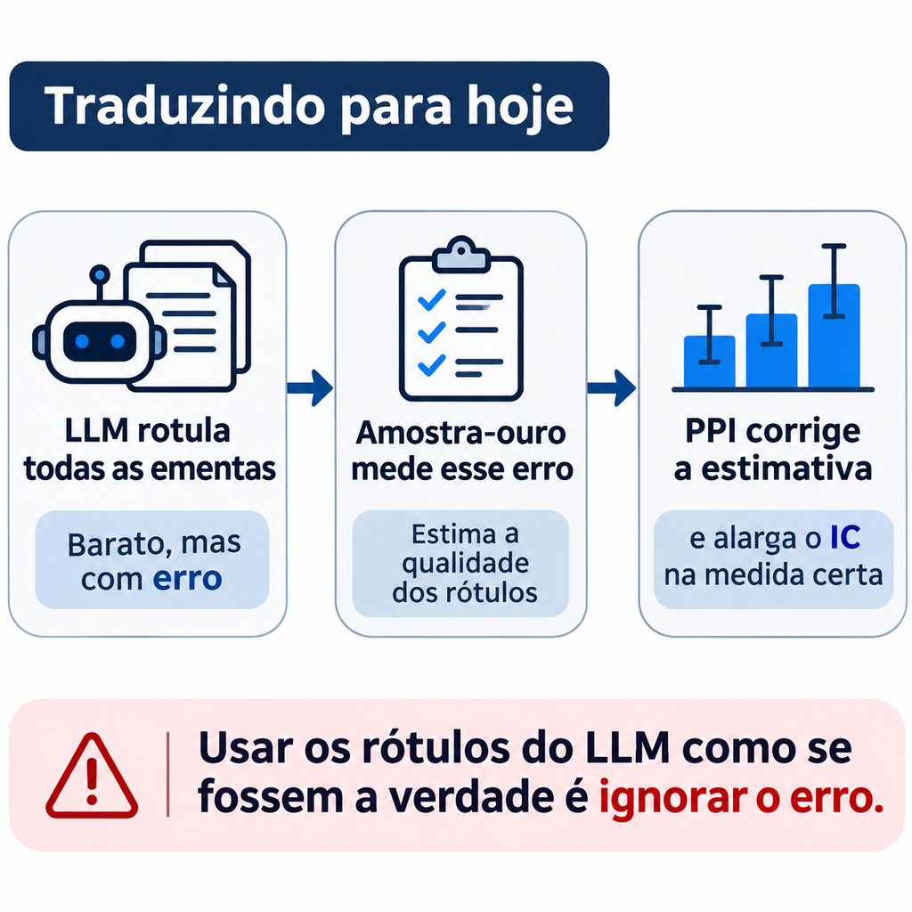

## O que significa medir um instrumento

| Propriedade | Pergunta | Como vamos medir hoje |
| --- | --- | --- |
| **Validade** | Mede o que diz medir? | kappa, F1 e acurácia contra a amostra-ouro, com IC bootstrap |
| **Onde erra** | Que erros comete? | matriz de confusão |
| **Viés diferencial** | Erra igual para todos? | acurácia e viés por campo político |
| **Confiabilidade** | Mede sempre igual? | alfa de Krippendorff entre sementes e entre prompts |
| **Consequência** | O erro muda a conclusão? | ingênuo × PPI × PPI++, simulação de cobertura |
| **Reprodutibilidade** | Outra pessoa chega ao mesmo número? | cache, hashes, `targets`, repetição |

## O caminho de hoje

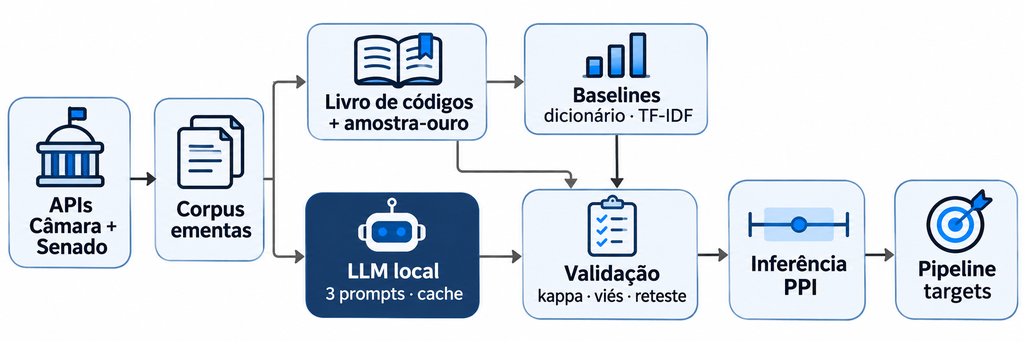

## Organização do material

```
minicurso_IA_medicao/
├── python/       medicao.py, anotar_llm.py + notebooks (Colab)
├── R/            a mesma trilha em R + funções
├── _targets.R    pipeline reprodutível (R)
├── prompts/      v1, v2, v3 + CHANGELOG
├── modelos/      Modelfile do S5-nano
├── dados/
│   ├── bruto/        respostas das APIs (congeladas)
│   ├── processado/   corpus.csv
│   ├── anotacoes/    referência, amostra-ouro
│   ├── cache_llm/    TODAS as respostas do LLM
│   └── repeticao/    repetição a t = 0
├── resultados/   tabelas e figuras
├── slides/  livro/  docs/
└── CODEBOOK.md  CHECKLIST.md  ROTEIRO.md
```

- Tudo roda **sem internet e sem GPU**, a partir de `dados/`
- O código dos slides é o **mesmo** de `python/`
- Abra o projeto na raiz: os caminhos são relativos a ela

## Preparando o ambiente

**Python** (uma vez):

```bash
pip install -r requirements.txt
```

```
# Trilha Python do minicurso (testado com Python 3.11)
pandas>=2.0
numpy>=1.24
requests>=2.31
scikit-learn>=1.3
matplotlib>=3.7
jupyter
# opcional (API comercial):
# openai>=1.40
```

ou abra `python/01_coleta.ipynb` no **Google Colab** (a primeira célula baixa o material).

**R** (alternativa):

```r
source("R/00_pacotes.R")
```

**LLM** (opcional, só para anotar de novo):

```bash
ollama pull hf.co/maritaca-ai/S5-nano-GGUF:Q4_K_M
ollama create s5-nano-instruct \
  -f modelos/Modelfile.s5-nano-instruct
```

## Carregando as funções do minicurso

```python
import sys
sys.path.insert(0, "python")     # a pasta python/ do material
from medicao import *            # APIs, kappa, alfa, F1, bootstrap, PPI, PPI++, tema das figuras
from anotar_llm import (chama_ollama, extrai_rotulo, anota,   # chamada ao Ollama,
                        PROMPTS, ESQUEMA, PLANO, sha)         # extração do rótulo, cache
estilo_graficos()                # tema e paleta das figuras

print(CATEGORIAS)
print(INSTRUMENTO)
import medicao, anotar_llm, inspect
funcoes = sorted(n for m in (medicao, anotar_llm)
                 for n, f in inspect.getmembers(m, inspect.isfunction)
                 if f.__module__ == m.__name__ and not n.startswith("_") and n != "main")
print(textwrap.fill("  ".join(funcoes), 95))
```

```
['PUNIR', 'REGULAR', 'PROMOVER', 'OUTRO']
s5-nano-instruct
alfa_krippendorff  anota  boot_ic  camara_autor  camara_partido_na_data  camara_proposicoes
camara_situacao  campo_politico  carrega_corpus  carrega_llm  carrega_ouro  chama_ollama
classifica_dicionario  compara_estimadores  digest_modelo  eleitoral_dicionario  est_humano
est_ingenuo  est_ppi  est_ppi_plus  estilo_graficos  extrai_partido_senado  extrai_rotulo
f1_macro  ic_normal  kappa_cohen  limpa_ementa  req_json  resumo_metricas  rotulo_run
senado_processos  sha  versao_ollama
```

## Os dados que vamos usar

```python
from pathlib import Path
arqs = [p for p in Path("dados").rglob("*") if p.is_file()]
tab = pd.DataFrame(dict(pasta=[str(p.parent) for p in arqs],
                        kb=[p.stat().st_size / 1024 for p in arqs]))
(tab[~tab["pasta"].str.contains("historico_gemma|comparacao_modelos")]
   .groupby("pasta").agg(arquivos=("kb", "size"), tamanho_kb=("kb", "sum"))
   .round().astype(int).reset_index())
```

|  | pasta | arquivos | tamanho_kb |
| --- | --- | --- | --- |
| 0 | dados/anotacoes | 4 | 25 |
| 1 | dados/bruto | 2 | 129 |
| 2 | dados/cache_llm | 6 | 757 |
| 3 | dados/processado | 1 | 116 |
| 4 | dados/processado/historico | 1 | 114 |
| 5 | dados/repeticao | 3 | 380 |

Esses arquivos **são** a pesquisa: quem tiver esta pasta refaz todas as análises, sem APIs nem LLM.

# 1 · Dados legislativos

## O que vamos executar neste bloco

1. Entender **uma requisição** às APIs da Câmara e do Senado
2. Ler as funções de coleta: **retry**, **limite de taxa**, **paginação**, **autor**, **partido na data**
3. As partes que transformam os dados: **partido no Senado**, **limpeza da ementa**, **campo político**
4. Como gerar **corpus** *congelado*
5. Comparar duas coletas feitas com um mês de diferença

## Duas APIs abertas, sem chave

### Câmara dos Deputados

`dadosabertos.camara.leg.br/api/v2`

- `/proposicoes`: busca por palavra-chave, ano, tipo
- `/proposicoes/{id}/autores`
- `/proposicoes/{id}` (situação)
- `/deputados/{id}/historico`

### Senado Federal

`legis.senado.leg.br/dadosabertos`

- `/processo`: busca por termo, sigla e datas
- a **autoria já vem com partido e UF** na data: “Senador Fulano (PSD/MG)”

**Termos:** *inteligência artificial*, *deepfake*, *deep fake*, *conteúdo sintético* · **Tipo:** PL · **Anos:** 2019–2026

## Anatomia de uma requisição

```
https://dadosabertos.camara.leg.br/api/v2/proposicoes?keywords=deepfake&ano=2024&siglaTipo=PL&itens=100&pagina=1
└──────────────── URL base ──────────────┘└ endpoint ┘└──────────────── parâmetros (query) ─────────────────┘
```

| Parâmetro | Papel | Decisão de medição |
| --- | --- | --- |
| `keywords` | termo de busca | o **indexador** da Câmara decide o que “contém” o termo |
| `ano` | ano de apresentação | o filtro por **data** aceita no máximo 3 meses |
| `siglaTipo` | PL, PEC, PLP… | só **projetos de lei** |
| `itens`, `pagina` | paginação | no máximo 100 por página |

## Uma chamada, em Python

```python
import requests
resp = requests.get("https://dadosabertos.camara.leg.br/api/v2/proposicoes",
                    params=dict(keywords="inteligência artificial", ano=2026,
                                siglaTipo="PL", itens=100),
                    headers={"Accept": "application/json"}, timeout=60)
dados = resp.json()["dados"]

len(dados)                # quantas proposições vieram nesta página
dados[0]["ementa"]        # a ementa da primeira
```

- `requests.get()` monta a URL com os parâmetros de `params` e faz a chamada
- `resp.json()` transforma o JSON num **dicionário** do Python
- Cada elemento de `dados` é uma proposição: `id`, `siglaTipo`, `numero`, `ano`, `ementa`, `dataApresentacao`

## O que ficou guardado da resposta

A coleta gravou as respostas, já em formato de tabela, em `dados/bruto/`:

```python
camara_raw = pd.read_csv("dados/bruto/camara_raw.csv")
print(camara_raw.shape)
camara_raw[["id", "sigla", "numero", "ano", "data_apresentacao", "autor", "partido", "uf"]].head(6)
```

```
(265, 14)
```

|  | id | sigla | numero | ano | data_apresentacao | autor | partido | uf |
| --- | --- | --- | --- | --- | --- | --- | --- | --- |
| 0 | 2236340 | PL | 21 | 2020 | 2020-02-04T11:57 | Eduardo Bismarck | PDT | CE |
| 1 | 2236943 | PL | 240 | 2020 | 2020-02-11T17:23 | Léo Moraes | PODE | RO |
| 2 | 2284814 | PL | 1969 | 2021 | 2021-05-26T16:54 | Gustavo Fruet | PDT | PR |
| 3 | 2318674 | PL | 705 | 2022 | 2022-03-24T16:16 | Helio Lopes | UNIÃO | RJ |
| 4 | 2343349 | PL | 3009 | 2022 | 2022-12-15T13:13 | Alexis Fonteyne | NOVO | SP |
| 5 | 2349685 | PL | 759 | 2023 | 2023-03-01T15:20 | Lebrão | UNIÃO | RO |

`id` é o identificador interno da Câmara; é com ele que pedimos autores e situação.

## Boas práticas com APIs públicas: `req_json()`

```python
def req_json(url, params=None, tentativas=4):
    """Requisição com retry e pausa (no máximo ~5 requisições/segundo)."""
    for t in range(tentativas):
        try:
            time.sleep(0.2)
            r = SESSAO.get(url, params=params, timeout=60)
            r.raise_for_status()
            return r.json()
        except requests.RequestException:
            if t == tentativas - 1:
                raise
            time.sleep(2 ** (t + 1))
```

- **`SESSAO`** (em `medicao.py`) envia um `User-Agent` que identifica quem está chamando · **`time.sleep(0.2)`**: no máximo 5 requisições por segundo
- **`for t in range(tentativas)`**: tenta de novo, com espera crescente (2, 4, 8 s…)
- **`raise_for_status()`** transforma erros **5xx** em exceção, que também é repetida. Na recoleta de 06/11, a Câmara respondeu **504** no meio da coleta

## Paginação: buscar até acabar

```python
def camara_proposicoes(termo, ano, tipos=("PL",)):
    """A API limita intervalos de datas a 3 meses; filtrar por `ano` evita isso."""
    saida, pagina = [], 1
    while True:
        res = req_json(f"{URL_CAMARA}/proposicoes",
                       dict(keywords=termo, ano=ano, siglaTipo=",".join(tipos), itens=100,
                            pagina=pagina, ordem="ASC", ordenarPor="id"))
        saida += res["dados"]
        if len(res["dados"]) < 100:
            break
        pagina += 1
    return pd.DataFrame([dict(id=x["id"], sigla=x["siglaTipo"], numero=x["numero"], ano=x["ano"],
                              ementa=x["ementa"], data_apresentacao=x["dataApresentacao"])
                         for x in saida])
```

`while True` pede a página 1, 2, 3… até vir uma página com **menos de 100** itens. No fim, `pd.DataFrame()` transforma a lista de proposições numa tabela, uma linha por proposição.

## Quem é o autor?

```python
def camara_autor(id_):
    """Primeiro autor (proponente) de uma proposição da Câmara."""
    res = req_json(f"{URL_CAMARA}/proposicoes/{id_}/autores")["dados"]
    if not res:
        return dict(id=id_)
    a = min(res, key=lambda x: x.get("ordemAssinatura") or 99)
    return dict(id=id_, autor=a["nome"], tipo_autor=a["tipo"], uri_autor=a.get("uri"),
                n_autores=len(res))
```

- Um PL pode ter **vários autores**: escolhemos o primeiro signatário (`ordemAssinatura`)
- `x.get("ordemAssinatura") or 99`: quando o campo vem vazio (`None`), o autor vai para o fim da fila
- Guardamos a **URI** do autor: é por ela que buscamos o partido
- `n_autores` fica registrado: projetos coletivos podem ser analisados à parte

## O partido de quem? E quando?

Queremos o partido do autor **na data de apresentação**, não o partido de hoje.

- A API da Câmara tem o **histórico** de cada deputado: `/deputados/{id}/historico`
- Armadilha: o histórico traz registros “partido no início da legislatura” **datados de 2023-02-01 para legislaturas antigas**, com `situacao` vazia
- Sem filtrar esses registros, um deputado do **PL em 2023** aparecia como **PMDB** ou **PFL** num projeto de 2023
- A solução é uma linha de código, mas só aparece para quem **olha os dados**

## `camara_partido_na_data()`

```python
def camara_partido_na_data(uri_deputado, data_ref):
    """Partido do deputado NA DATA da apresentação (não o partido atual!)."""
    vazio = dict(partido=None, uf=None)
    if not isinstance(uri_deputado, str) or "/deputados/" not in uri_deputado:
        return vazio
    h = req_json(f"{uri_deputado}/historico")["dados"]
    # Atenção: a API inclui registros "Nome/Partido no início da legislatura" com a
    # data de 2023-02-01 para TODAS as legislaturas anteriores (situacao = None).
    # Sem este filtro, um deputado do PL em 2023 aparece como PMDB ou PFL.
    h = sorted([dict(dia=(x.get("dataHora") or "")[:10], partido=x.get("siglaPartido"),
                     uf=x.get("siglaUf"))
                for x in h if x.get("siglaPartido") and x.get("dataHora") and x.get("situacao")],
               key=lambda x: x["dia"])
    if not h:
        return vazio
    antes = [x for x in h if x["dia"] <= str(data_ref)[:10]]
    linha = antes[-1] if antes else h[0]
    return dict(partido=linha["partido"], uf=linha["uf"])
```

## Testando a regra

Um histórico **fictício**, com o registro problemático da API:

```python
h = pd.DataFrame([
    ("2007-02-01", "PFL",  "SP", None),          # "início da legislatura" com data errada
    ("2023-02-01", "PMDB", "SP", None),          # idem: é isto que a API devolve
    ("2019-02-01", "PSL",  "SP", "Exercício"),
    ("2022-03-30", "PL",   "SP", "Exercício"),
], columns=["dia", "partido", "uf", "situacao"])
data_ref = "2023-05-10"

ingenuo = h[h["dia"] <= data_ref].sort_values("dia").tail(1)
correto = h[h["situacao"].notna() & (h["dia"] <= data_ref)].sort_values("dia").tail(1)
pd.concat([ingenuo, correto], keys=["ingenuo", "correto"], names=["regra"]).reset_index(level=0)
```

|  | regra | dia | partido | uf | situacao |
| --- | --- | --- | --- | --- | --- |
| 1 | ingenuo | 2023-02-01 | PMDB | SP | None |
| 3 | correto | 2022-03-30 | PL | SP | Exercício |

## Senado: o partido vem no texto

No Senado, a autoria já vem com partido e UF **na data**. Basta extrair com uma expressão regular:

```python
def extrai_partido_senado(autoria):
    m = re.search(r"\(([A-Za-zÀ-ú ]+)/([A-Z]{2})\)", autoria or "")
    return (m.group(1), m.group(2)) if m else (None, None)
```

```python
autorias = ["Senador Styvenson Valentim (PODEMOS/RN)",
            "Senadora Daniella Ribeiro (PSD/PB)",
            "Comissão de Comunicação e Direito Digital"]
[extrai_partido_senado(a) for a in autorias]
```

```
[('PODEMOS', 'RN'), ('PSD', 'PB'), (None, None)]
```

Autoria de **comissão** não tem partido: vira `None` e, mais adiante, “Sem partido/Outro”.

## Limpeza mínima e transparente da ementa

```python
def limpa_ementa(x):
    x = re.sub(r"[\r\n]+", " ", x)
    x = re.sub(r"(?i)\s*NOVA EMENTA:.*$", "", x)    # mantém a ementa original
    return re.sub(r"\s+", " ", x).strip()
```

Um caso real da Câmara, em que a ementa foi **reescrita** durante a tramitação:

```python
bruta = camara_raw.loc[camara_raw["id"] == 2236340, "ementa"].iloc[0]
print(textwrap.fill(bruta, 100), "\n")
print(textwrap.fill(limpa_ementa(bruta), 100))
```

```
Estabelece princípios, direitos e deveres para o uso de inteligência artificial no Brasil, e dá
outras providências.  NOVA EMENTA: Estabelece fundamentos, princípios e diretrizes para o
desenvolvimento e a aplicação da inteligência artificial no Brasil; e dá outras providências.

Estabelece princípios, direitos e deveres para o uso de inteligência artificial no Brasil, e dá
outras providências.
```

*Decisão de medição:* ficamos com a ementa **original**, a que o autor apresentou.

## Montando o corpus (trecho de `python/01_coleta.ipynb`)

```python
corpus = (pd.concat([senado_pad, camara_pad], ignore_index=True)
          .drop_duplicates("identificacao")            # PL do Senado remetido à Câmara: fica o da origem
          .assign(ementa=lambda d: d["ementa"].map(limpa_ementa),
                  partido=lambda d: d["partido"].str.strip().str.upper()))
corpus = corpus[corpus["ano"].isin(ANOS) & (corpus["ementa"].str.len() > 20)]
corpus = corpus.sort_values("data_apresentacao", kind="stable")   # ordem estável: doc_id não muda numa recoleta
corpus.insert(0, "doc_id", [f"doc{i:04d}" for i in range(1, len(corpus) + 1)])

corpus.to_csv("dados/processado/corpus.csv", index=False)
```

- `drop_duplicates("identificacao")` remove a **duplicata** entre casas
- `sort_values("data_apresentacao")` + `doc_id`: o identificador de cada projeto fica **estável** entre coletas
- O corpus é salvo **com a data da coleta** (`data_coleta`)

## Campo político: uma medida dentro da medida

```python
ESQUERDA = {"PSOL", "PT", "PCDOB", "PDT", "PSB", "REDE", "PV"}
CENTRO   = {"MDB", "PSDB", "CIDADANIA", "PSD", "SOLIDARIEDADE", "AVANTE", "PMB"}
DIREITA  = {"PL", "PP", "UNIÃO", "REPUBLICANOS", "NOVO", "PSC", "PTB", "PODE", "PODEMOS",
            "PATRIOTA", "PRD", "DEM", "PSL", "PROS", "PRTB", "AGIR", "DC", "PMN", "MOBILIZA"}
corpus = pd.read_csv("dados/processado/corpus.csv")
campo2 = corpus["partido"].map(lambda p: "Esquerda" if p in ESQUERDA else "Centro" if p in CENTRO
                               else "Direita" if p in DIREITA else "Sem partido/Outro")
corpus.assign(campo2=campo2).value_counts(["campo2", "campo"]).sort_index().reset_index(name="n")
```

|  | campo2 | campo | n |
| --- | --- | --- | --- |
| 0 | Centro | Centro | 61 |
| 1 | Direita | Direita | 155 |
| 2 | Esquerda | Esquerda | 80 |
| 3 | Sem partido/Outro | Sem partido/Outro | 8 |

## O corpus

```python
print(corpus.shape)
pd.DataFrame({"tipo": corpus.dtypes.astype(str),
              "exemplo": corpus.iloc[0].astype(str).str.slice(0, 70)})
```

```
(304, 14)
```

|  | tipo | exemplo |
| --- | --- | --- |
| doc_id | object | doc0001 |
| casa | object | Senado |
| identificacao | object | PL 5051/2019 |
| ano | int64 | 2019 |
| data_apresentacao | object | 2019-09-16 |
| ementa | object | Estabelece os princípios para o uso da Inteligência Artificial no ... |
| autor | object | Senador Styvenson Valentim |
| tipo_autor | object | Senador(a) |
| partido | object | PODEMOS |
| uf | object | RN |
| situacao | object | nan |
| campo | object | Direita |
| ano_eleitoral | bool | False |
| data_coleta | object | 2026-11-06 |

## Quantos projetos, de onde e quando?

```python
display(pd.crosstab(corpus["casa"], corpus["ano"]))

tab = pd.crosstab(corpus["campo"], corpus["casa"])
tab.assign(Total=tab["Câmara"] + tab["Senado"])
```

| ano casa | 2019 | 2020 | 2021 | 2022 | 2023 | 2024 | 2025 | 2026 |
| --- | --- | --- | --- | --- | --- | --- | --- | --- |
| Câmara | 0 | 1 | 1 | 2 | 34 | 43 | 73 | 106 |
| Senado | 2 | 0 | 2 | 2 | 6 | 12 | 6 | 14 |

| casa campo | Câmara | Senado | Total |
| --- | --- | --- | --- |
| Centro | 47 | 14 | 61 |
| Direita | 138 | 17 | 155 |
| Esquerda | 74 | 6 | 80 |
| Sem partido/Outro | 1 | 7 | 8 |

## Quem mais apresenta?

```python
(corpus.dropna(subset=["partido"])
   .value_counts(["partido", "campo"]).reset_index(name="n")
   .assign(prop=lambda d: (d["n"] / d["n"].sum()).round(3))
   .head(10))
```

|  | partido | campo | n | prop |
| --- | --- | --- | --- | --- |
| 0 | PT | Esquerda | 42 | 0.142 |
| 1 | PL | Direita | 40 | 0.135 |
| 2 | PODE | Direita | 31 | 0.105 |
| 3 | REPUBLICANOS | Direita | 30 | 0.101 |
| 4 | MDB | Centro | 26 | 0.088 |
| 5 | UNIÃO | Direita | 24 | 0.081 |
| 6 | PP | Direita | 16 | 0.054 |
| 7 | PDT | Esquerda | 13 | 0.044 |
| 8 | PSD | Centro | 12 | 0.041 |
| 9 | CIDADANIA | Centro | 11 | 0.037 |

8 projetos não têm partido (comissões, Executivo, Senado Federal como autor).

## A explosão legislativa: o código

```python
ref = pd.read_csv("dados/anotacoes/referencia_completa.csv")

cont = (corpus.merge(ref[["doc_id", "categoria"]], on="doc_id", how="left")
        .pipe(lambda d: pd.crosstab(d["ano"], d["categoria"]))[CATEGORIAS])
fig, eixos = plt.subplots(1, 4, figsize=(10, 4.6), sharey=True)
for ax, cat in zip(eixos, CATEGORIAS):
    ax.bar(cont.index.astype(str), cont[cat], width=.7,
           color=AZUIS[2] if cat == "PUNIR" else CINZA_CLARO)
    ax.set_title(cat, fontsize=10, loc="center"); ax.tick_params(axis="x", rotation=90)
    ax.grid(axis="x", visible=False)
eixos[0].set_ylabel("Projetos")
fig.suptitle("Projetos de lei sobre IA no Congresso, por ano e categoria (referência)",
             x=0.01, ha="left", fontweight="bold")
plt.tight_layout(); plt.show()
```

## A explosão legislativa: o código

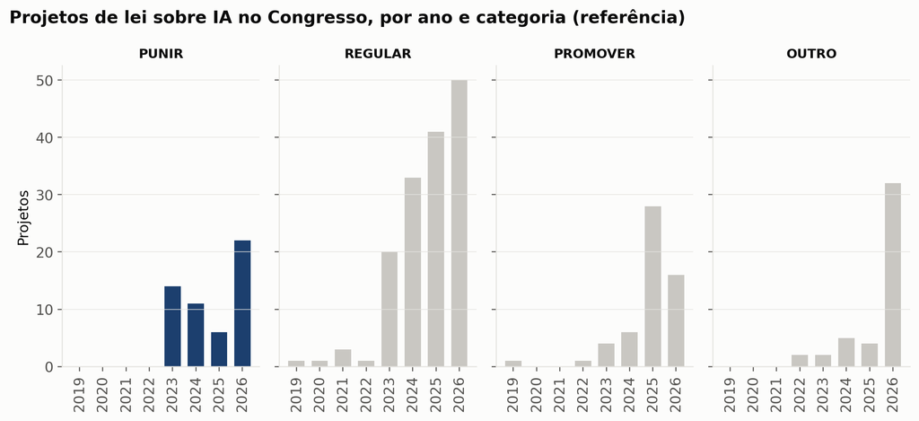

## Duplicatas: o mesmo PL nas duas casas

```python
senado_raw = pd.read_csv("dados/bruto/senado_raw.csv")
display(senado_raw.loc[senado_raw["identificacao"] == "PL 2338/2023",
                       ["identificacao", "data_apresentacao", "autoria", "situacao"]])
display(camara_raw.loc[(camara_raw["numero"] == 2338) & (camara_raw["ano"] == 2023),
                       ["sigla", "numero", "ano", "data_apresentacao", "autor"]])
corpus.loc[corpus["identificacao"] == "PL 2338/2023", ["doc_id", "casa", "identificacao", "partido", "campo"]]
```

|  | identificacao | data_apresentacao | autoria | situacao |
| --- | --- | --- | --- | --- |
| 7 | PL 2338/2023 | 2023-05-03 | Senador Rodrigo Pacheco (PSD/MG) | REMETIDA À CÂMARA DOS DEPUTADOS |

|  | sigla | numero | ano | data_apresentacao | autor |
| --- | --- | --- | --- | --- | --- |
| 39 | PL | 2338 | 2023 | 2025-03-17T17:21 | Senado Federal - Rodrigo Pacheco |

|  | doc_id | casa | identificacao | partido | campo |
| --- | --- | --- | --- | --- | --- |
| 17 | doc0018 | Senado | PL 2338/2023 | PSD | Centro |

O Marco Legal da IA aparece nas duas casas. Mantemos o registro do **Senado** (casa de origem), que traz o partido do autor na data.

## A mesma coleta, um mês depois

```python
antigo = pd.read_csv("dados/processado/historico/corpus_2026-10-08.csv")
novos  = corpus[~corpus["identificacao"].isin(antigo["identificacao"])]
sairam = antigo[~antigo["identificacao"].isin(corpus["identificacao"])]
comum  = antigo.merge(corpus, on="identificacao", suffixes=("_out", "_nov"))
muda_sit = int((comum["situacao_out"].fillna("") != comum["situacao_nov"].fillna("")).sum())

display(pd.DataFrame([dict(coleta_08_10=len(antigo), coleta_06_11=len(corpus), novos=len(novos),
                           sairam=len(sairam),
                           ementa_mudou=int((comum["ementa_out"] != comum["ementa_nov"]).sum()),
                           situacao_mudou=muda_sit)]))
novos[["doc_id", "casa", "identificacao", "data_apresentacao"]]
```

|  | coleta_08_10 | coleta_06_11 | novos | sairam | ementa_mudou | situacao_mudou |
| --- | --- | --- | --- | --- | --- | --- |
| 0 | 298 | 304 | 6 | 0 | 0 | 46 |

|  | doc_id | casa | identificacao | data_apresentacao |
| --- | --- | --- | --- | --- |
| 298 | doc0299 | Câmara | PL 5580/2026 | 2026-10-15 |
| 299 | doc0300 | Câmara | PL 5606/2026 | 2026-10-19 |
| 300 | doc0301 | Câmara | PL 5715/2026 | 2026-10-30 |
| 301 | doc0302 | Câmara | PL 5716/2026 | 2026-10-30 |
| 302 | doc0303 | Senado | PL 5726/2026 | 2026-11-03 |
| 303 | doc0304 | Câmara | PL 5729/2026 | 2026-11-03 |

## A coleta também é medição

- **Limite de 3 meses** no filtro de data → filtrar por `ano`
- **Partido “na data”**: registros de 2023 para legislaturas antigas → filtrar `situacao`
- **Busca por palavra-chave** depende de um indexador: falsos positivos (Lei Geral das Atividades Nucleares?) e possíveis omissões → categoria **OUTRO**
- **Duplicatas** entre casas → `drop_duplicates("identificacao")`
- **Erros 5xx** no meio da coleta → `req_json()` repete, com espera crescente
- **APIs mudam**: em um mês, 6 projetos novos e 46 situações de tramitação diferentes → **congelar com data**

## Resumo do bloco 1

**Executamos**

- leitura dos dados brutos e do corpus
- regras de partido (Câmara e Senado)
- limpeza da ementa e campo político
- descrição do corpus e comparação entre coletas

**Levamos para os próximos blocos**

- `corpus`: 304 ementas, uma por projeto
- `doc_id` estável
- `campo` do autor (para o viés diferencial)
- a lição: **cada passo da coleta é uma decisão de medição**

# 2 · Codificar é medir

## O que vamos executar neste bloco

1. **Livro de Códigos**: categorias, regras de decisão, variável eleitoral
2. **Ementas difíceis** e discutir como codificá-las
3. **Codificação de referência**: quem a fez, como, e seu status
4. Contar **quantos de cada classe** e ver **o que foi parar em OUTRO**
5. **Selecionar a amostra-ouro** com semente fixa e conferir que o sorteio é reproduzível

**Por que este bloco vem antes do LLM**

Um LLM só pode ser avaliado contra uma **referência**. E uma referência só existe se o conceito tiver uma **definição operacional** escrita.

## Livro de códigos

| Código | Instrumento central | Exemplo |
| --- | --- | --- |
| **PUNIR** | *penal:* crime, pena, Código Penal, parte penal do ECA | “tipifica o crime de deepfake sexual” |
| **REGULAR** | *regras não penais:* deveres, rotulagem, direitos, responsabilidade civil | “obriga identificar conteúdo gerado por IA” |
| **PROMOVER** | fomento, ensino, adoção de IA pelo Estado | “inclui IA no currículo do ensino médio” |
| **OUTRO** | não trata de IA, algoritmos ou conteúdo sintético | falsos positivos da busca |

**Unidade de análise:** a **ementa**, sozinha. Sem inteiro teor, sem olhar o autor.

## Regras de decisão

1. **Precedência:** PUNIR > REGULAR > PROMOVER
2. “Responsabilização” ou “penalidades” **sem** crime, pena ou Código Penal → **REGULAR**
3. Marcos gerais (“princípios, direitos e deveres”) → **REGULAR**
4. Proteção de trabalhadores diante da automação → **REGULAR**
5. Obrigar o Estado ou empresas a **usar** IA → **PROMOVER**
6. Deepfake, montagem, nudez falsa = conteúdo sintético, mesmo sem “inteligência artificial”
7. Na dúvida com OUTRO: *a ementa, sozinha, deixa claro que o objeto é IA?*

**Segunda variável:** `eleitoral` (0/1), independente da categoria: eleições, campanhas, candidatos, Código Eleitoral, violência política.

## A codificação de referência

```python
ref = pd.read_csv("dados/anotacoes/referencia_completa.csv")
display(ref.head(4))
ref.value_counts(["codificador", "revisado"]).reset_index(name="n")
```

|  | doc_id | categoria | eleitoral | codificador | revisado | obs |
| --- | --- | --- | --- | --- | --- | --- |
| 0 | doc0001 | REGULAR | 0 | preliminar | False | NaN |
| 1 | doc0002 | PROMOVER | 0 | preliminar | False | NaN |
| 2 | doc0003 | REGULAR | 0 | preliminar | False | NaN |
| 3 | doc0004 | REGULAR | 0 | preliminar | False | NaN |

|  | codificador | revisado | n |
| --- | --- | --- | --- |
| 0 | preliminar | False | 304 |

## De onde vêm os rótulos de referência?

- As 304 ementas têm um rótulo de **referência**: é a “régua” do minicurso
- **Quem codificou:** outra IA, o **Claude Opus 5.5** (Anthropic), coautor deste material. **Não** é o S5-nano, o instrumento que vamos avaliar
- **Como:** aplicando o **livro de códigos** ementa por ementa, lendo **só a ementa** (sem autor, sem inteiro teor);
- **Quando:** 298 ementas da coleta de 08/10/2026 e as 6 novas da coleta de 06/11/2026

**O que isso muda**

Sem revisão humana, o kappa do bloco 5 mede a concordância **entre duas IAs** (S5-nano × Claude), não a validade contra humanos. Se as duas erram nos mesmos casos, a concordância **infla**.

Os números **ensinam o método**; não são achados sobre o Congresso.

**Pergunta para a turma**

Por que não aceitar o rótulo do Claude como “verdade” e dispensar os humanos?

## Quantos de cada classe?

```python
d = corpus.merge(ref, on="doc_id")
tab = pd.crosstab(d["categoria"], d["casa"]).loc[CATEGORIAS]
tab["Total"] = tab["Câmara"] + tab["Senado"]
tab["%"] = (100 * tab["Total"] / tab["Total"].sum()).round(1)
tab
```

| casa categoria | Câmara | Senado | Total | % |
| --- | --- | --- | --- | --- |
| PUNIR | 40 | 13 | 53 | 17.4 |
| REGULAR | 136 | 14 | 150 | 49.3 |
| PROMOVER | 47 | 9 | 56 | 18.4 |
| OUTRO | 37 | 8 | 45 | 14.8 |

- **Total:** 304 ementas · **REGULAR é metade** do corpus: chutar sempre REGULAR é o **piso** de qualquer instrumento

## O que foi parar em OUTRO?

45 ementas (14,8% do corpus, 32 delas de 2026) vieram na busca, mas a **ementa, sozinha, não trata de IA nem de conteúdo sintético** (regra 7).

| Tipo | Exemplos reais do corpus (ementas resumidas) |
| --- | --- |
| **Temas digitais vizinhos**, sem IA na ementa | violência contra a mulher em ambiente digital · crimes cibernéticos · LGPD para crianças · inclusão e soberania digital · nuvem soberana |
| **Leis penais** que não citam IA nem conteúdo sintético | aumento de pena dos arts. 216-B e 218-C do Código Penal · estelionato · usura · ameaça pelo Pix |
| **Falsos positivos puros** | Lei Geral das Atividades Nucleares · transplante de órgãos · Código de Trânsito · processo administrativo |

**Por que vieram?** A busca das APIs não olha só a ementa (o indexador usa também outros campos, como a indexação do projeto), e o texto completo pode até tratar de IA. Mas a unidade de análise é a **ementa**.

**Pergunta para a turma**

A proporção PUNIR deve ser calculada sobre as 304 ementas ou só sobre as que tratam de IA?

Sobre 304: 17,4% · sobre 259: 20,5%. O denominador é uma **decisão de medição** (aqui, as 304).

## A amostra-ouro: um sorteio

```python
N_OURO = 120      # ~40% do corpus: custo humano × precisão
sorteio = lambda: np.random.default_rng(2026).choice(corpus["doc_id"], N_OURO, replace=False)
print(sorteio()[:12])
print("mesma semente, mesmo sorteio:", (sorteio() == sorteio()).all())

# a amostra oficial foi sorteada em R (R/02_amostra_ouro.R): o Python a lê do arquivo
ouro = pd.read_csv("dados/anotacoes/amostra_ouro.csv")
ouro_ids = ouro["doc_id"]
print(len(ouro_ids), "ementas na amostra-ouro;", len(set(sorteio()) & set(ouro_ids)), "em comum com o sorteio do Python")
```

```
['doc0156' 'doc0122' 'doc0044' 'doc0242' 'doc0005' 'doc0063' 'doc0162'
 'doc0231' 'doc0296' 'doc0085' 'doc0003' 'doc0137']
mesma semente, mesmo sorteio: True
120 ementas na amostra-ouro; 50 em comum com o sorteio do Python
```

- **Aleatória:** nem a “mais fácil”, nem a “mais interessante”. É o que permite que o erro medido nela valha para o corpus todo
- **Semente fixa:** qualquer pessoa sorteia **as mesmas** 120 ementas, **com o mesmo gerador**: R e Python sorteiam diferente com a mesma semente

## A amostra-ouro representa o corpus?

```python
conj = pd.concat([ref.assign(conjunto="corpus"),
                  ref[ref["doc_id"].isin(ouro_ids)].assign(conjunto="amostra_ouro")])
n = pd.crosstab(conj["categoria"], conj["conjunto"])[["corpus", "amostra_ouro"]]
pd.concat({"n": n, "prop": (n / n.sum()).round(2)}, axis=1)
```

| conjunto categoria | n corpus | n amostra_ouro | prop corpus | prop amostra_ouro |
| --- | --- | --- | --- | --- |
| OUTRO | 45 | 13 | 0.15 | 0.11 |
| PROMOVER | 56 | 16 | 0.18 | 0.13 |
| PUNIR | 53 | 22 | 0.17 | 0.18 |
| REGULAR | 150 | 69 | 0.49 | 0.57 |

Proporções parecidas, como se espera de um sorteio. Diferenças existem, e é por isso que a inferência leva a amostra em conta.

## Quanto **nós** concordamos?

**Levantem a mão:** PUNIR, REGULAR, PROMOVER ou OUTRO?

1. *“Estabelece condições, deveres e restrições ao uso de óculos inteligentes com recursos de inteligência artificial, altera o Código de Trânsito Brasileiro e o Código Penal…”* (doc0185)
2. *“Dispõe sobre medidas de prevenção, combate e responsabilização relacionadas à criação e disseminação de manipulação digital de conteúdo sexual (deepfakes)…”* (doc0233)

**Referência:**

1 → **PUNIR** (altera o Código Penal; PUNIR precede REGULAR)

2 → **REGULAR** (“responsabilização” sem crime nem pena;regra 2).

## Por que isso importa

**O teto do instrumento**

Se humanos treinados não concordam entre si, o LLM **não tem um alvo**. A concordância humano × humano é o **teto realista** de qualquer instrumento automático.

- Kappa de 0,65 entre LLM e referência é **ruim** se humanos concordam a 0,90…
  - …e é **excelente** se eles concordam a 0,60
- Por isso o livro de códigos é testado **com humanos** antes de ir para o LLM
- Neste material ainda não há dois codificadores humanos:
  - o teto humano é **desconhecido**

## Resumo do bloco 2

**Executamos**

- leitura da referência: quem a fez e seu status
- contagem das classes e o que foi para OUTRO
- sorteio reproduzível da amostra-ouro
- comparação ouro × corpus

**Levamos para os próximos blocos**

- `ouro`:
  - 120 ementas com rótulo de referência (preliminar, de outra IA)
- o livro de códigos, que vira **prompt** no bloco 4
- a pergunta:
  - **qual é o teto de concordância?**

# 3 · Baselines: quanto se acerta **sem** LLM?

## O que vamos executar neste bloco

1. Um **dicionário**: expressões regulares que traduzem o livro de códigos em regras
2. As **métricas** de acerto, implementadas “na mão”: acurácia, F1, **kappa**
3. Um modelo clássico: **TF-IDF + regressão logística**, com **validação cruzada**
4. A comparação com o **piso**: alocar sempre para a classe mais frequente

**Por que baselines**

Um LLM só “vale a pena” se superar instrumentos mais baratos e mais transparentes **de forma estatisticamente consistente**. Isso é uma afirmação a testar, não uma impressão.

## O dicionário: regras explícitas

```python
print(list(REGEX))
print(REGEX["punir"])
print(textwrap.fill(REGEX["ia"], 100))
print(textwrap.fill(REGEX["promover"], 100))
```

```
['punir', 'ia', 'promover', 'eleitoral']
c[oó]digo penal|\bpenas?\b|\bcrimes?\b|criminaliz|tipific|hediond
intelig[eê]ncia artificial|\bia\b|algor[ií]tm|automatiz|automa[cç][aã]o|sint[eé]tic|deep
?fake|deepvoice|manipula|chatbot|reconhecimento facial|aut[oô]nom|\binteligente|réplicas?
digit|simul
incentiv|fomento|\bfundo\b|curr[ií]cul|ensino|educa[cç]|capacita|forma[cç][aã]o|pesquisa|desenvolvim
ento da|programa nacional|institui o sistema|obrigatoriedade d[eo] uso|utiliza[cç][aã]o de
(ferramentas|tecnologias|sistemas)
```

## Função para classificar para as regras

```python
def classifica_dicionario(ementa):
    x = ementa.lower()
    tem_ia = re.search(REGEX["ia"], x)
    if re.search(REGEX["punir"], x) and tem_ia:
        return "PUNIR"
    if not tem_ia:
        return "OUTRO"
    if re.search(REGEX["promover"], x):
        return "PROMOVER"
    return "REGULAR"
```

- Os `if` avaliam as regras **em ordem**: a primeira verdadeira vence (`return`)
- A ordem implementa a **precedência** do livro de códigos (PUNIR > … )
- Sem termo de IA → **OUTRO** (falso positivo da busca)
- Barato, transparente, **100% auditável**

## Testando o dicionário

```python
exemplos = [
    "Altera o Código Penal para tipificar a criação de deepfake de nudez.",
    "Dispõe sobre a rotulagem de conteúdo gerado por inteligência artificial.",
    "Institui programa de formação em inteligência artificial nas escolas.",
    "Altera a Lei nº 9.503 para dispor sobre a carteira de habilitação.",
    "Prevê penalidades administrativas para plataformas que não removam deepfakes.",
    "Cria o crime de fraude eletrônica com uso de algoritmos."]
pd.DataFrame(dict(ementa=exemplos,
                  dicionario=[classifica_dicionario(e) for e in exemplos],
                  eleitoral=[eleitoral_dicionario(e) for e in exemplos]))
```

|  | ementa | dicionario | eleitoral |
| --- | --- | --- | --- |
| 0 | Altera o Código Penal para tipificar a criação de deepfake de nudez. | PUNIR | False |
| 1 | Dispõe sobre a rotulagem de conteúdo gerado por inteligência artif... | REGULAR | False |
| 2 | Institui programa de formação em inteligência artificial nas escolas. | PROMOVER | False |
| 3 | Altera a Lei nº 9.503 para dispor sobre a carteira de habilitação. | OUTRO | False |
| 4 | Prevê penalidades administrativas para plataformas que não removam... | REGULAR | False |
| 5 | Cria o crime de fraude eletrônica com uso de algoritmos. | PUNIR | False |

A 5ª ementa: “penalidades” sem crime, REGULAR pelo livro de códigos. O dicionário acertou porque `\bpenas?\b` não casa com “penalidades”.

## Aplicando à amostra-ouro

```python
ouro = (pd.read_csv("dados/anotacoes/amostra_ouro.csv")
        .merge(corpus[["doc_id", "ementa"]], on="doc_id", how="left"))
ouro["pred_dic"] = ouro["ementa"].map(classifica_dicionario)

(ouro.assign(ementa=ouro["ementa"].str.slice(0, 70) + "…")
     .rename(columns={"categoria": "humano", "pred_dic": "dicionario"})
     [["doc_id", "humano", "dicionario", "ementa"]].head(8))
```

|  | doc_id | humano | dicionario | ementa |
| --- | --- | --- | --- | --- |
| 0 | doc0001 | REGULAR | REGULAR | Estabelece os princípios para o uso da Inteligência Artificial no ... |
| 1 | doc0003 | REGULAR | REGULAR | Cria a Lei da Inteligência Artificial, e dá outras providências.… |
| 2 | doc0004 | REGULAR | REGULAR | Dispõe sobre o uso da Inteligência Artificial.… |
| 3 | doc0012 | PROMOVER | REGULAR | Estabelece procedimentos a serem adotados pela União em regime de ... |
| 4 | doc0013 | REGULAR | REGULAR | Altera a Lei nº 9.504, de 30 de setembro de 1997, que estabelece n... |
| 5 | doc0014 | REGULAR | PROMOVER | Dispõe sobre normas gerais para a pesquisa, o desenvolvimento e a ... |
| 6 | doc0017 | REGULAR | REGULAR | Esta Lei torna obrigatória a disponibilização, por parte das empre... |
| 7 | doc0018 | REGULAR | REGULAR | Dispõe sobre o uso da Inteligência Artificial.… |

## Matriz de confusão — Caso multiclasse

Linhas representam as classes reais e colunas as classes preditas. **Diagonal principal:** classificações corretas.

$$\begin{array}{c|ccc|c}
& \hat{C}_1 & \hat{C}_2 & \hat{C}_3 & \text{Total}\\
\hline
C_1 & n_{11} & n_{12} & n_{13} & n_{1\cdot}\\
C_2 & n_{21} & n_{22} & n_{23} & n_{2\cdot}\\
C_3 & n_{31} & n_{32} & n_{33} & n_{3\cdot}\\
\hline
\text{Total} & n_{\cdot1} & n_{\cdot2} & n_{\cdot3} & N
\end{array}$$

- $n_{ij}$: exemplos da classe real $C_i$ preditos como $C_j$.
- $n_{i\cdot}=\sum_j n_{ij}$: total da classe real $C_i$.
- $n_{\cdot j}=\sum_i n_{ij}$: total predito como $\hat{C}_j$.
- $N=\sum_i\sum_j n_{ij}$: total de exemplos.

## Como medir o desempenho?

Para cada classe $C_c$, considerando as demais como uma única classe:

$$TP_c=n_{cc},\quad
FP_c=n_{\cdot c}-n_{cc},\quad
FN_c=n_{c\cdot}-n_{cc}$$

**Acurácia**

$$\text{Acc}=
\frac{\sum_{c=1}^{C}n_{cc}}{N}$$

**Precisão**

$$P_c=\frac{TP_c}{TP_c+FP_c}$$

**Revocação (Recall)**

$$R_c=\frac{TP_c}{TP_c+FN_c}$$

**F1 macro**

$$F1_{\text{macro}}=
\frac{1}{C}\sum_{c=1}^{C}
\frac{2P_cR_c}{P_c+R_c}$$

**Destaque:** o F1 macro atribui o mesmo peso a todas as classes, inclusive às raras.

## Concordância além do acaso

O Kappa desconta da concordância observada aquela esperada ao acaso.

$$\kappa=\frac{p_o-p_e}{1-p_e}$$

**Concordância observada**

$$p_o=\frac{\sum_{c=1}^{C}n_{cc}}{N}$$

**Concordância esperada ao acaso**

$$p_e=\sum_{c=1}^{C}
\frac{n_{c\cdot}}{N}
\frac{n_{\cdot c}}{N}$$

## O kappa do dicionário, passo a passo

```python
tab = pd.crosstab(pd.Categorical(ouro["categoria"], CATEGORIAS),
                  pd.Categorical(ouro["pred_dic"], CATEGORIAS),
                  rownames=["humano"], colnames=["dic"], dropna=False)
n  = tab.values.sum()
po = np.trace(tab.values) / n
pe = (tab.sum(axis=1).values * tab.sum(axis=0).values).sum() / n ** 2
print(dict(po=round(po, 7), pe=round(pe, 7), kappa=round((po - pe) / (1 - pe), 7)))
kappa_cohen(ouro["categoria"], ouro["pred_dic"])
```

```
{'po': 0.8083333, 'pe': 0.3634722, 'kappa': 0.6988872}
```

```
0.698887191795767
```

## O dicionário na amostra-ouro

```python
met_dic = resumo_metricas(ouro["categoria"], ouro["pred_dic"])
display(pd.DataFrame([met_dic]).round(3))
tab
```

|  | n | falhas_formato | acuracia | f1_macro | kappa |
| --- | --- | --- | --- | --- | --- |
| 0 | 120 | 0.0 | 0.808 | 0.782 | 0.699 |

| dic humano | PUNIR | REGULAR | PROMOVER | OUTRO |
| --- | --- | --- | --- | --- |
| PUNIR | 20 | 0 | 0 | 2 |
| REGULAR | 1 | 55 | 11 | 2 |
| PROMOVER | 0 | 5 | 11 | 0 |
| OUTRO | 0 | 1 | 1 | 11 |

Linhas: humano. Colunas: dicionário. A diagonal são os acertos.

## TF-IDF: texto vira número

Cada ementa vira um vetor com um peso por palavra (após limpeza):

$$\text{tf-idf}(t, d) = \underbrace{\text{tf}(t, d)}_{\text{frequência na ementa}} \times \underbrace{\left[\log\frac{1 + D}{1 + \text{df}(t)} + 1\right]}_{\text{raridade no corpus}}$$

- Palavras comuns a todas as ementas (“dispõe”, “lei”) pesam pouco
- Palavras raras e específicas (“tipifica”, “currículo”) pesam muito
- Sobre esses vetores, ajustamos uma **regressão logística multinomial** com penalização *L2*

## Preparando a matriz documento-termo

```python
from sklearn.feature_extraction.text import TfidfVectorizer
vetorizador = lambda: TfidfVectorizer(
    lowercase=True, stop_words=STOPWORDS_PT,       # minúsculas, sem stopwords
    token_pattern=r"(?u)\b[^\W\d_]{2,}\b",         # sem pontuação nem números
    min_df=2)                                      # termos em pelo menos 2 ementas
vet = vetorizador()
X = vet.fit_transform(ouro["ementa"]); y = ouro["categoria"]
print(X.shape)
peso = pd.Series(np.asarray(X.sum(axis=0)).ravel(), index=vet.get_feature_names_out())
peso.sort_values(ascending=False).head(12).round(2).to_frame("soma do tf-idf").T
```

```
(120, 313)
```

|  | artificial | inteligência | lei | sobre | nº | altera | uso | dispõe | outras | providências | dá | sistemas |
| --- | --- | --- | --- | --- | --- | --- | --- | --- | --- | --- | --- | --- |
| soma do tf-idf | 9.97 | 9.9 | 9.5 | 7.95 | 7.47 | 7.07 | 6.76 | 6.43 | 6.31 | 5.98 | 5.85 | 5.42 |

## Validação cruzada com 10 dobras

```python
from sklearn.linear_model import LogisticRegressionCV
from sklearn.model_selection import StratifiedKFold, cross_val_predict
from sklearn.pipeline import make_pipeline
modelo = make_pipeline(vetorizador(),     # o vetorizador fica DENTRO: o idf só vê o treino
                       LogisticRegressionCV(Cs=10, cv=5, max_iter=5000, scoring="accuracy"))
dobras = StratifiedKFold(n_splits=10, shuffle=True, random_state=2026)
pred_ml = cross_val_predict(modelo, ouro["ementa"], y, cv=dobras)
ouro["pred_ml"] = pred_ml
print("ementas em cada dobra de teste:", [len(teste) for _, teste in dobras.split(ouro["ementa"], y)])
```

```
ementas em cada dobra de teste: [12, 12, 12, 12, 12, 12, 12, 12, 12, 12]
```

Cada ementa é classificada por um modelo que **não a viu** no treino. Com $n$ = 120, é a única forma honesta de medir o acerto.

## TF-IDF na amostra-ouro

```python
met_ml = resumo_metricas(ouro["categoria"], pred_ml)
display(pd.DataFrame([met_ml]).round(3))
pd.crosstab(pd.Categorical(y, CATEGORIAS), pd.Categorical(pred_ml, CATEGORIAS),
            rownames=["humano"], colnames=["tfidf"], dropna=False)
```

|  | n | falhas_formato | acuracia | f1_macro | kappa |
| --- | --- | --- | --- | --- | --- |
| 0 | 120 | 0.0 | 0.725 | 0.565 | 0.508 |

| tfidf humano | PUNIR | REGULAR | PROMOVER | OUTRO |
| --- | --- | --- | --- | --- |
| PUNIR | 16 | 5 | 0 | 1 |
| REGULAR | 2 | 62 | 3 | 2 |
| PROMOVER | 0 | 6 | 8 | 2 |
| OUTRO | 0 | 9 | 3 | 1 |

## Comparando os baselines

```python
maj = ["REGULAR"] * len(ouro)
baselines = pd.DataFrame([
    {"metodo": "Dicionário (regex)",           **met_dic},
    {"metodo": "TF-IDF + logística (CV 10)",   **met_ml},
    {"metodo": "Classe majoritária (REGULAR)", **resumo_metricas(ouro["categoria"], maj)}])
baselines.round(3)
```

|  | metodo | n | falhas_formato | acuracia | f1_macro | kappa |
| --- | --- | --- | --- | --- | --- | --- |
| 0 | Dicionário (regex) | 120 | 0.0 | 0.808 | 0.782 | 0.699 |
| 1 | TF-IDF + logística (CV 10) | 120 | 0.0 | 0.725 | 0.565 | 0.508 |
| 2 | Classe majoritária (REGULAR) | 120 | 0.0 | 0.575 | 0.183 | 0.000 |

**Nota**

A classe majoritária acerta 57%, mas tem **kappa zero**: não acerta nada além do acaso. Com classes desbalanceadas, a acurácia sozinha engana.

## O dicionário “viu a prova”

**Data leakage**

As regras do dicionário foram escritas **depois de ler as ementas do corpus**. Seu kappa (0,70) é **otimista**.

- Num estudo real: regras definidas **antes**, ou validadas em **dados novos** (projetos apresentados depois da coleta)
- O mesmo vale para o LLM: os exemplos do prompt v3 são **fictícios** por esse motivo
- E vale para a **escolha do modelo**: se a amostra-ouro foi usada para escolher, o kappa do vencedor também é otimista

## O “mesmo” método, duas implementações

```python
base_r = pd.read_csv("resultados/tabelas/baselines.csv")
(pd.concat([baselines.assign(trilha="Python"), base_r.assign(trilha="R")])
   [["trilha", "metodo", "acuracia", "f1_macro", "kappa"]]
   .sort_values(["metodo", "trilha"]).round(3).reset_index(drop=True))
```

|  | trilha | metodo | acuracia | f1_macro | kappa |
| --- | --- | --- | --- | --- | --- |
| 0 | Python | Classe majoritária (REGULAR) | 0.575 | 0.183 | 0.000 |
| 1 | R | Classe majoritária (REGULAR) | 0.575 | 0.183 | 0.000 |
| 2 | Python | Dicionário (regex) | 0.808 | 0.782 | 0.699 |
| 3 | R | Dicionário (regex) | 0.808 | 0.782 | 0.699 |
| 4 | Python | TF-IDF + logística (CV 10) | 0.725 | 0.565 | 0.508 |
| 5 | R | TF-IDF + logística (CV 10) | 0.683 | 0.501 | 0.407 |

- R: `glmnet` (elastic-net + *stemming*).
- Python: `scikit-learn` (L2, sem *stemming*).
- “TF-IDF + logística” é uma **família** de escolhas, e cada escolha precisa ser relatada.

## Resumo do bloco 3

**Executamos**

- dicionário em ementas de teste e na amostra-ouro
- acurácia, F1 macro e kappa “na mão”
- TF-IDF + logística com validação cruzada

**Levamos para os próximos blocos**

- a régua: kappa do dicionário 0,70, do TF-IDF 0,51
- `kappa_cohen()` e `resumo_metricas()`
- a desconfiança saudável:
  - **quem viu a prova?**

# 4 · O LLM como instrumento

## O que vamos executar neste bloco

1. Conhecer o instrumento: **S5-nano** (Maritaca AI), local, via **Ollama**
2. Montar a **chamada** ao modelo: esquema JSON, temperatura, semente, modo *instruct*
3. Ler os **três prompts** e calcular o **hash** de cada um
4. Testar a **extração do rótulo** em respostas “sujas”
5. Entender o laço de anotação com **cache e retomada**

## Um modelo brasileiro, aberto e local

- **Brasileiro:** desenvolvido pela Maritaca AI, com pré-treinamento adicional em **português**, a língua (e o vocabulário jurídico-legislativo) das ementas
- **Vem do Qwen:** parte do **Qwen3.5-4B** (Alibaba) e herda a arquitetura, o tokenizador e boa parte do que “sabe”
- **Aberto e pequeno:** Apache-2.0, pesos públicos (todos baixam **a mesma versão**), roda numa GPU de notebook
- **Local:** os dados não saem da máquina, custo zero, e **a versão não muda sem aviso**

**Aviso**

“Brasileiro” **não garante validade**: é uma característica do treinamento. A validade se mede na amostra-ouro.

## Instalando o instrumento

```bash
# 1. instalar o Ollama: https://ollama.com
ollama pull hf.co/maritaca-ai/S5-nano-GGUF:Q4_K_M                       # ~3,5 GB
ollama create s5-nano-instruct -f modelos/Modelfile.s5-nano-instruct    # nome local
ollama list
```

O `Modelfile` também é versionado:

```python
mf = open("modelos/Modelfile.s5-nano-instruct", encoding="utf-8").read().splitlines()
print("\n".join(mf[0:3] + mf[9:14] + mf[-1:]))
```

```
# S5-nano (Maritaca AI) em modo INSTRUCT: o instrumento de medição do minicurso.
#
# Pesos: GGUF oficial quantizado em 4 bits (Q4_K_M, ~2,8 GB + 0,7 GB do módulo de visão),
# A Maritaca publica UM modelo com dois modos: "think" (raciocina antes de responder) e
# "instruct" (responde direto). O modo é escolhido em cada chamada: o template oficial,
# embutido no GGUF, abre o bloco <think> vazio quando o cliente envia "think": false.
# Por isso o modo instruct é garantido pelo código (python/anotar_llm.py e
# R/04_anotacao_llm.R enviam sempre "think": false e rejeitam respostas com raciocínio),
FROM hf.co/maritaca-ai/S5-nano-GGUF:Q4_K_M
```

## Quantização: outro instrumento

- Pesos originais: 16 bits por parâmetro (BF16)
- **Q4_K_M**:
  - 4 bits por parâmetro → cabe em 6 GB de GPU
- O modelo quantizado **é outro instrumento**: os resultados publicados pela Maritaca (BF16) não valem automaticamente para ele
- O que vale é a validação feita **aqui**, com o modelo que de fato usamos

**O que registrar**

- nome **e digest** dos pesos
- versão do **Ollama**
- prompt (**hash**)
- temperatura e semente
- **resposta bruta**

## A chamada: o que vai para o modelo

```python
corpo = dict(
    model="s5-nano-instruct",
    stream=False,
    think=False,          # modo instruct
    format=ESQUEMA,       # saída estruturada
    options=dict(temperature=0,
                 seed=42),  # registrar!
    messages=[dict(
        role="user",
        content="<prompt com a ementa>")])
print(json.dumps(corpo, indent=2, ensure_ascii=False))
```

```
{
  "model": "s5-nano-instruct",
  "stream": false,
  "think": false,
  "format": {
    "type": "object",
    "properties": {
      "categoria": {
        "type": "string",
        "enum": [
          "PUNIR",
          "REGULAR",
          "PROMOVER",
          "OUTRO"
        ]
      },
      "eleitoral": {
        "type": "boolean"
      }
    },
    "required": [
      "categoria",
      "eleitoral"
    ]
  },
  "options": {
    "temperature": 0,
    "seed": 42
  },
  "messages": [
    {
      "role": "user",
      "content": "<prompt com a ementa>"
    }
  ]
}
```

## `chama_ollama()`

```python
def chama_ollama(modelo, prompt, temperatura, semente, timeout=120):
    """Modo instruct: "think": False em toda chamada. O S5-nano tem também um modo
    que raciocina antes de responder; se vier raciocínio, a chamada é tratada como erro."""
    r = requests.post(
        f"{OLLAMA}/api/chat",
        json={
            "model": modelo,
            "stream": False,
            "think": False,
            "format": ESQUEMA,
            "options": {"temperature": temperatura, "seed": semente},
            "messages": [{"role": "user", "content": prompt}],
        },
        timeout=timeout,
    )
    r.raise_for_status()
    msg = r.json()["message"]
    if msg.get("thinking"):
        raise RuntimeError("o modelo devolveu raciocínio: o modo instruct não foi respeitado")
    return msg["content"]
```

- `requests.post()` envia o corpo do slide anterior para `http://localhost:11434/api/chat`
- `timeout=120`: uma ementa que trava não trava a anotação inteira
- Se vier **raciocínio** (`thinking`), a função **para com erro**: seria outro instrumento

## O prompt é parte do instrumento

| Versão | Arquivo | Conteúdo |
| --- | --- | --- |
| **v1** | `prompt_v1_simples.txt` | só os nomes das categorias |
| **v2** | `prompt_v2_codebook.txt` | + definições e regras do livro de códigos |
| **v3** | `prompt_v3_fewshot.txt` | + 6 exemplos **fictícios** (*few-shot*) |

```python
from pathlib import Path
arq_prompts = sorted(Path("prompts").glob("prompt_v*_*.txt"))
pd.DataFrame(dict(arquivo=[a.name for a in arq_prompts],
                  linhas=[len(a.read_text(encoding="utf-8").splitlines()) for a in arq_prompts],
                  caracteres=[a.stat().st_size for a in arq_prompts]))
```

|  | arquivo | linhas | caracteres |
| --- | --- | --- | --- |
| 0 | prompt_v1_simples.txt | 5 | 254 |
| 1 | prompt_v2_codebook.txt | 18 | 1569 |
| 2 | prompt_v3_fewshot.txt | 32 | 2555 |

## Prompt v1: só as categorias

```python
print(open("prompts/prompt_v1_simples.txt", encoding="utf-8").read())
```

```
Classifique a ementa de projeto de lei abaixo em UMA categoria: PUNIR, REGULAR, PROMOVER ou OUTRO.
Indique também se o tema é eleitoral (true/false).
Responda apenas em JSON no formato {"categoria": "...", "eleitoral": true/false}.

Ementa: {{ementa}}
```

**Pergunta para a turma:** o que o modelo “entende” sozinho por PUNIR, REGULAR e PROMOVER? `{ementa}` é substituído pelo texto de cada ementa.

## Prompt v2: o livro de códigos no prompt

```python
v2 = open("prompts/prompt_v2_codebook.txt", encoding="utf-8").read().splitlines()
print("\n".join(textwrap.fill(l, 140) for l in v2))
```

```
Você é um codificador de pesquisa em Ciência Política. Classifique a ementa de um projeto de lei brasileiro segundo o livro de códigos
abaixo. Use APENAS o texto da ementa.

CATEGORIAS (escolha exatamente uma):
- PUNIR: o instrumento central é penal: cria crime, tipifica conduta, criminaliza, aumenta ou qualifica pena, altera o Código Penal, a parte
penal do ECA ou cria crime eleitoral.
- REGULAR: estabelece regras não penais para o uso de IA: princípios, deveres, obrigações, proibições administrativas, direitos,
transparência, rotulagem, auditoria, responsabilidade civil ou administrativa, proteção de dados, direitos autorais, proteção do consumidor
ou do trabalhador, campanhas de prevenção.
- PROMOVER: fomenta ou adota IA: incentivos, fundos, pesquisa, ensino de IA em currículos, capacitação, ou uso de IA pelo Estado em
políticas públicas.
- OUTRO: a ementa não trata de IA, algoritmos, automação ou conteúdo sintético/manipulado digitalmente.

REGRAS:
1. Se houver mais de um instrumento, a precedência é PUNIR > REGULAR > PROMOVER.
2. "Responsabilização" ou "penalidades" sem menção a crime, pena ou Código Penal = REGULAR.
3. Deepfake, montagem ou nudez falsa contam como conteúdo sintético.

ELEITORAL: true se a ementa trata de eleições, campanhas, propaganda eleitoral, candidatos, Código Eleitoral, período eleitoral, violência
política ou processo democrático; false caso contrário.

Responda apenas em JSON: {"categoria": "PUNIR|REGULAR|PROMOVER|OUTRO", "eleitoral": true|false}

Ementa: {{ementa}}
```

## Prompt v3: + exemplos fictícios

```python
v3 = open("prompts/prompt_v3_fewshot.txt", encoding="utf-8").read().splitlines()
ini = next(i for i, l in enumerate(v3) if l.startswith("EXEMPLOS"))
print("\n".join(textwrap.fill(l, 130) for l in v3[ini:]))
```

```
EXEMPLOS (fictícios):
Ementa: "Altera o Código Penal para tipificar a clonagem de voz por inteligência artificial com fins de extorsão."
{"categoria": "PUNIR", "eleitoral": false}
Ementa: "Obriga plataformas digitais a rotular conteúdos gerados por inteligência artificial durante o período de campanha
eleitoral."
{"categoria": "REGULAR", "eleitoral": true}
Ementa: "Cria o Programa Nacional de Bolsas para Formação em Inteligência Artificial nas universidades públicas."
{"categoria": "PROMOVER", "eleitoral": false}
Ementa: "Dispõe sobre o uso de sistemas de IA na triagem de pacientes das unidades básicas de saúde."
{"categoria": "PROMOVER", "eleitoral": false}
Ementa: "Estabelece deveres de transparência para chatbots e prevê sanções administrativas ao fornecedor."
{"categoria": "REGULAR", "eleitoral": false}
Ementa: "Altera a Lei nº 9.503 para dispor sobre a renovação da carteira de habilitação de idosos."
{"categoria": "OUTRO", "eleitoral": false}

Responda apenas em JSON: {"categoria": "PUNIR|REGULAR|PROMOVER|OUTRO", "eleitoral": true|false}

Ementa: {{ementa}}
```

## O hash do prompt: uma impressão digital

```python
import hashlib
def hash_prompt(arq):
    txt = Path(arq).read_text(encoding="utf-8")                  # o mesmo texto que vai para o modelo
    return hashlib.sha256(txt.encode("utf-8")).hexdigest()[:12]  # = sha() de anotar_llm.py
hashes = pd.DataFrame(dict(prompt_id=[re.search(r"v\d", a.name).group() for a in arq_prompts],
                           sha_arquivo=[hash_prompt(a) for a in arq_prompts]))
llm = carrega_llm(".")
hashes.merge(llm[["prompt_id", "prompt_sha"]].drop_duplicates()
                .rename(columns={"prompt_sha": "sha_no_cache"}), on="prompt_id", how="left")
```

|  | prompt_id | sha_arquivo | sha_no_cache |
| --- | --- | --- | --- |
| 0 | v1 | 5eb0f92ea13d | 5eb0f92ea13d |
| 1 | v2 | c4b5a5ade801 | c4b5a5ade801 |
| 2 | v3 | 6fdbfaf1d613 | 6fdbfaf1d613 |

Mudou uma vírgula no prompt → muda o hash → as respostas antigas no cache **não** correspondem ao prompt atual. É assim que se descobre.

## Extraindo o rótulo da resposta

````python
def extrai_rotulo(resposta: str):
    """Extrai o JSON da resposta. Modelos pequenos às vezes devolvem ```json ... ```
    ou texto extra; contar essas falhas também faz parte da avaliação do instrumento."""
    m = re.search(r"\{.*?\}", resposta, flags=re.S)
    if not m:
        return None, None
    try:
        d = json.loads(m.group(0))
    except json.JSONDecodeError:
        return None, None
    cat = str(d.get("categoria", d.get("classificacao", ""))).strip().upper()
    ele = d.get("eleitoral")
    if isinstance(ele, str):
        ele = ele.strip().lower() in ("true", "sim", "1")
    return (cat if cat in CATEGORIAS else None), (bool(ele) if ele is not None else None)
````

- Procura o **primeiro objeto JSON** na resposta, mesmo com texto em volta
- Aceita um nome alternativo de campo (`classificacao`)
- Categoria fora da lista → `None`:
  - uma **falha de formato**, que será **contada**

## Testando com respostas “sujas”

````python
respostas = dict(
    limpa      = '{"categoria": "PUNIR", "eleitoral": false}',
    markdown   = '```json\n{"categoria": "REGULAR", "eleitoral": true}\n```',
    texto      = 'Claro! A classificação é {"categoria": "promover", "eleitoral": false}.',
    outro_nome = '{"classificacao": "OUTRO", "eleitoral": false}',
    invalida   = '{"categoria": "PUNIÇÃO", "eleitoral": false}',
    sem_json   = 'A ementa trata de inteligência artificial.')
pd.DataFrame([extrai_rotulo(r) for r in respostas.values()],
             index=pd.Index(respostas, name="caso"), columns=["categoria", "eleitoral"]).reset_index()
````

|  | caso | categoria | eleitoral |
| --- | --- | --- | --- |
| 0 | limpa | PUNIR | False |
| 1 | markdown | REGULAR | True |
| 2 | texto | PROMOVER | False |
| 3 | outro_nome | OUTRO | False |
| 4 | invalida | None | False |
| 5 | sem_json | None | None |

## O laço de anotação com cache

```python
# trecho de anota() em python/anotar_llm.py
run_id  = f"{modelo_tag}__{prompt_id}__t{temperatura}__s{semente}"
destino = RAIZ / pasta / f"{run_id}.jsonl"
feitos  = {json.loads(l)["doc_id"] for l in destino.open()} if destino.exists() else set()
pendentes = corpus[~corpus.doc_id.isin(feitos)]                 # retomada: só o que falta

with destino.open("a", encoding="utf-8") as f:
    for row in pendentes.itertuples():
        prompt = modelo_prompt.replace("{{ementa}}", row.ementa)
        try:
            bruto = chama_ollama(modelo, prompt, temperatura, semente)
        except Exception as e:
            bruto = f"ERRO: {e}"                                  # registra a falha
        cat, ele = extrai_rotulo(bruto)
        registro = {"doc_id": row.doc_id, "modelo_digest": digest, "ollama_versao": versao,
                    "prompt_id": prompt_id, "prompt_sha": prompt_sha, "temperatura": temperatura,
                    "semente": semente, "resposta_bruta": bruto, "categoria_llm": cat}  # ...
        f.write(json.dumps(registro, ensure_ascii=False) + "\n")  # uma linha JSON por ementa
```

## Demonstração ao vivo: 5 ementas

```python
corpus = carrega_corpus(".")
anota(corpus.head(5), modelo="s5-nano-instruct", prompt_id="v2",
      temperatura=0.0, semente=7)
```

```
[s5-nano-instruct__v2__t0.0__s7] 0 em cache, 5 pendentes
 doc_id                               resposta_bruta categoria_llm  eleitoral_llm  segundos
doc0001 {"categoria": "REGULAR", "eleitoral": false}       REGULAR          False     0.451
doc0002 {"categoria": "REGULAR", "eleitoral": false}       REGULAR          False     0.384
doc0003 {"categoria": "REGULAR", "eleitoral": false}       REGULAR          False     0.383
doc0004 {"categoria": "REGULAR", "eleitoral": false}       REGULAR          False     0.382
doc0005 {"categoria": "REGULAR", "eleitoral": false}       REGULAR          False     0.385
```

A saída acima vem do cache com semente 42 (as mesmas 5 ementas).

## Um registro do cache, completo

```python
primeiro = open("dados/cache_llm/s5-nano-instruct__v2__t0.0__s42.jsonl", encoding="utf-8").readline()
print(json.dumps(json.loads(primeiro), indent=2, ensure_ascii=False))
```

```
{
  "doc_id": "doc0001",
  "run_id": "s5-nano-instruct__v2__t0.0__s42",
  "modelo": "s5-nano-instruct",
  "modelo_digest": "85ec77c8f04e",
  "ollama_versao": "0.40.15",
  "prompt_id": "v2",
  "prompt_sha": "c4b5a5ade801",
  "temperatura": 0.0,
  "semente": 42,
  "resposta_bruta": "{\"categoria\": \"REGULAR\", \"eleitoral\": false}",
  "categoria_llm": "REGULAR",
  "eleitoral_llm": false,
  "segundos": 0.451,
  "timestamp": "2026-11-12T02:38:40+00:00"
}
```

## O cache inteiro

```python
print(sorted(p.name for p in Path("dados/cache_llm").glob("*.jsonl")))
llm.value_counts(["run_id", "prompt_id", "temperatura", "semente"]).sort_index().reset_index(name="n")
```

```
['s5-nano-instruct__v1__t0.0__s42.jsonl', 's5-nano-instruct__v2__t0.0__s42.jsonl', 's5-nano-instruct__v2__t0.8__s1.jsonl', 's5-nano-instruct__v2__t0.8__s2.jsonl', 's5-nano-instruct__v2__t0.8__s3.jsonl', 's5-nano-instruct__v3__t0.0__s42.jsonl']
```

|  | run_id | prompt_id | temperatura | semente | n |
| --- | --- | --- | --- | --- | --- |
| 0 | s5-nano-instruct__v1__t0.0__s42 | v1 | 0.0 | 42 | 304 |
| 1 | s5-nano-instruct__v2__t0.0__s42 | v2 | 0.0 | 42 | 304 |
| 2 | s5-nano-instruct__v2__t0.8__s1 | v2 | 0.8 | 1 | 304 |
| 3 | s5-nano-instruct__v2__t0.8__s2 | v2 | 0.8 | 2 | 304 |
| 4 | s5-nano-instruct__v2__t0.8__s3 | v2 | 0.8 | 3 | 304 |
| 5 | s5-nano-instruct__v3__t0.0__s42 | v3 | 0.0 | 42 | 304 |

Seis execuções:

- três prompts a temperatura 0 (semente 42) e o prompt v2 a temperatura 0,8 com três sementes (para o teste-reteste).

## Quanto custa medir?

```python
(llm.groupby(["prompt_id", "temperatura"])
    .agg(ementas=("segundos", "size"), seg_media=("segundos", "mean"),
         seg_max=("segundos", "max"), minutos_total=("segundos", lambda s: s.sum() / 60))
    .round(2).reset_index())
```

|  | prompt_id | temperatura | ementas | seg_media | seg_max | minutos_total |
| --- | --- | --- | --- | --- | --- | --- |
| 0 | v1 | 0.0 | 304 | 0.36 | 0.94 | 1.81 |
| 1 | v2 | 0.0 | 304 | 0.41 | 0.46 | 2.07 |
| 2 | v2 | 0.8 | 912 | 0.36 | 0.58 | 5.42 |
| 3 | v3 | 0.0 | 304 | 0.44 | 0.58 | 2.25 |

Numa GPU de notebook (RTX 4050, 6 GB):

- menos de um segundo por ementa.

O prompt v3 é maior (exemplos), e por isso um pouco mais lento.

## Falhas de formato

```python
display(llm.groupby("run_id")
           .agg(n=("doc_id", "size"), falhas=("categoria_llm", lambda s: int(s.isna().sum())),
                json_puro=("resposta_bruta", lambda s: s.str.fullmatch(r"\{.*\}").mean()))
           .reset_index())
llm["resposta_bruta"].value_counts().head(3).reset_index()
```

|  | run_id | n | falhas | json_puro |
| --- | --- | --- | --- | --- |
| 0 | s5-nano-instruct__v1__t0.0__s42 | 304 | 0 | 1.0 |
| 1 | s5-nano-instruct__v2__t0.0__s42 | 304 | 0 | 1.0 |
| 2 | s5-nano-instruct__v2__t0.8__s1 | 304 | 0 | 1.0 |
| 3 | s5-nano-instruct__v2__t0.8__s2 | 304 | 0 | 1.0 |
| 4 | s5-nano-instruct__v2__t0.8__s3 | 304 | 0 | 1.0 |
| 5 | s5-nano-instruct__v3__t0.0__s42 | 304 | 0 | 1.0 |

|  | resposta_bruta | count |
| --- | --- | --- |
| 0 | {"categoria": "REGULAR", "eleitoral": false} | 937 |
| 1 | {"categoria": "PUNIR", "eleitoral": false} | 370 |
| 2 | {"categoria": "PROMOVER", "eleitoral": false} | 345 |

Com saída estruturada, zero falhas aqui. Com outro prompt, modelo ou versão do Ollama, pode não ser zero, e a taxa de falhas é **uma propriedade do instrumento**.

## O mesmo modelo, três prompts

```python
t0 = llm[llm["temperatura"] == 0]
dist = pd.crosstab(t0["categoria_llm"], t0["prompt_id"], normalize="columns").reindex(CATEGORIAS)
dist["referencia"] = ref["categoria"].value_counts(normalize=True).reindex(CATEGORIAS)
dist.round(3).reset_index()
```

| prompt_id | categoria_llm | v1 | v2 | v3 | referencia |
| --- | --- | --- | --- | --- | --- |
| 0 | PUNIR | 0.204 | 0.230 | 0.224 | 0.174 |
| 1 | REGULAR | 0.632 | 0.516 | 0.490 | 0.493 |
| 2 | PROMOVER | 0.155 | 0.191 | 0.207 | 0.184 |
| 3 | OUTRO | 0.010 | 0.062 | 0.079 | 0.148 |

Antes de qualquer métrica, a **distribuição** já mostra:

- o prompt muda a medida.

## E com uma API comercial?

```python
from openai import OpenAI
# a chave NUNCA vai no código: use uma variável de ambiente (OPENAI_API_KEY=...)
cliente = OpenAI()
prompt = PROMPTS["v2"].read_text(encoding="utf-8").replace("{{ementa}}", corpus["ementa"][0])
r = cliente.chat.completions.create(
    model="gpt-4.1-mini", temperature=0, seed=42,
    response_format={"type": "json_object"},
    messages=[{"role": "user", "content": prompt}])
print(r.model, r.choices[0].message.content)    # registre r.model e a data
```

- Mesma lógica: esquema, temperatura, semente, **cache**
- APIs comerciais **trocam a versão do modelo sem aviso**: registre o identificador exato e a **data**, e guarde as respostas brutas

## Resumo do bloco 4

**Executamos**

- o corpo da chamada e o esquema JSON
- leitura dos prompts e cálculo dos hashes
- extração de rótulos em respostas “sujas”
- leitura e descrição do cache

**Levamos para os próximos blocos**

- `llm`:
  - 1824 respostas, 6 execuções
- instrumento = **modelo + prompt + parâmetros + software**
- o cache **é dado**: auditoria, retomada e replicação sem GPU

# 5 · Validação: o instrumento mede o que diz medir?

## O que vamos executar neste bloco

1. **Validade:** comparar cada instrumento com a amostra-ouro, com **IC bootstrap**
2. **Onde erra:** matriz de confusão e as ementas que o LLM erra
3. **Viés diferencial:** o erro é igual entre campos políticos?
4. **Confiabilidade:** alfa de Krippendorff entre **sementes** e entre **prompts**
5. A variável **eleitoral** e a concordância **humano × humano**

## Quatro perguntas

| Pergunta | Propriedade | Ferramenta |
| --- | --- | --- |
| Ele acerta? | validade | acurácia, F1, kappa + IC 95% |
| Onde erra? | estrutura do erro | matriz de confusão |
| Erra igual para todos? | viés diferencial | acurácia e viés em PUNIR por campo |
| Mede sempre igual? | confiabilidade | alfa de Krippendorff |

As duas primeiras precisam de rótulo humano.

A última, **não**:

- estabilidade se mede comparando o instrumento com ele mesmo.

## Juntando LLM e amostra-ouro

```python
def rotulo_run(run_id):
    p, t, s = re.search(r"__(v\d)__t([0-9.]+)__s(\d+)", run_id).groups()
    return f"LLM {p} (t=0)" if (t == "0.0" and s == "42") else f"LLM {p} (t={t}, s={s})"

llm["instrumento"] = llm["run_id"].map(rotulo_run)
aval = llm.merge(ouro[["doc_id", "categoria"]], on="doc_id")

aval.groupby("instrumento").size().rename("n").to_frame()
```

| instrumento | n |
| --- | --- |
| LLM v1 (t=0) | 120 |
| LLM v2 (t=0) | 120 |
| LLM v2 (t=0.8, s=1) | 120 |
| LLM v2 (t=0.8, s=2) | 120 |
| LLM v2 (t=0.8, s=3) | 120 |
| LLM v3 (t=0) | 120 |

## Métricas pontuais de cada instrumento

```python
pontual = pd.DataFrame([{"instrumento": nome, **resumo_metricas(d["categoria"], d["categoria_llm"])}
                        for nome, d in aval.groupby("instrumento")])
pontual.set_index("instrumento").sort_values("kappa", ascending=False).round(3)
```

| instrumento | n | falhas_formato | acuracia | f1_macro | kappa |
| --- | --- | --- | --- | --- | --- |
| LLM v2 (t=0) | 120 | 0.0 | 0.850 | 0.788 | 0.753 |
| LLM v3 (t=0) | 120 | 0.0 | 0.842 | 0.793 | 0.750 |
| LLM v2 (t=0.8, s=1) | 120 | 0.0 | 0.833 | 0.757 | 0.727 |
| LLM v2 (t=0.8, s=2) | 120 | 0.0 | 0.833 | 0.757 | 0.727 |
| LLM v2 (t=0.8, s=3) | 120 | 0.0 | 0.833 | 0.757 | 0.727 |
| LLM v1 (t=0) | 120 | 0.0 | 0.725 | 0.551 | 0.524 |

Com $n$ = 120, qual diferença entre essas linhas é **real**? Precisamos de intervalos.

## Bootstrap: a incerteza de uma métrica

```python
def boot_ic(verdade, pred, fun=kappa_cohen, B=2000, semente=2026):
    """Intervalo bootstrap percentil para qualquer métrica de (verdade, pred)."""
    rng = np.random.default_rng(semente)
    v, p = np.asarray(verdade, dtype=object), np.asarray(pred, dtype=object)
    n = len(v)
    est = []
    for _ in range(B):
        i = rng.integers(0, n, n)
        est.append(fun(v[i], p[i]))
    return np.nanquantile(est, [0.025, 0.975])
```

1. Sorteie 120 ementas **com reposição**
2. Calcule o kappa nessa amostra
3. Repita 2.000 vezes
4. O IC 95% vai do percentil 2,5 ao 97,5

## O bootstrap do LLM v2, por dentro

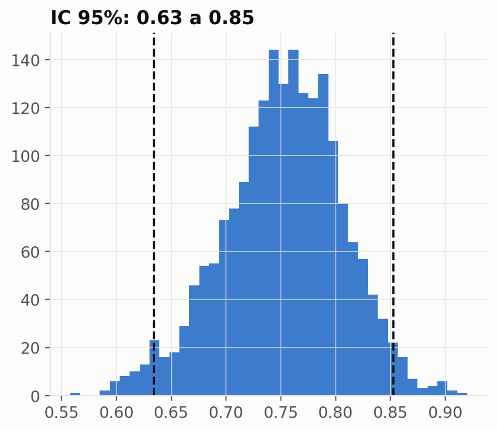

```python
d = aval[aval["instrumento"] == "LLM v2 (t=0)"]
v, p = d["categoria"].values, d["categoria_llm"].values
rng = np.random.default_rng(2026)
boot = []
for _ in range(2000):
    i = rng.integers(0, len(d), len(d))
    boot.append(kappa_cohen(v[i], p[i]))
ic = np.quantile(boot, [.025, .975])
fig, ax = plt.subplots(figsize=(5.5, 4.6))
ax.hist(boot, bins=40, color=AZUIS[1])
for x in ic:
    ax.axvline(x, color=TINTA, ls="--")
ax.set_title(f"IC 95%: {ic[0]:.2f} a {ic[1]:.2f}")
plt.show()
```

## A tabela de validade

```python
linhas = []
for nome, d in aval.groupby("instrumento"):
    li, ls = boot_ic(d["categoria"], d["categoria_llm"])
    linhas.append({"instrumento": nome, **resumo_metricas(d["categoria"], d["categoria_llm"]),
                   "kappa_li": li, "kappa_ls": ls})
metricas_llm = pd.DataFrame(linhas)
linhas = []
for nome, pred in [("Dicionário (regex)", ouro["pred_dic"]),
                   ("TF-IDF + logística (CV 10)", ouro["pred_ml"])]:
    li, ls = boot_ic(ouro["categoria"], pred)
    linhas.append({"instrumento": nome, **resumo_metricas(ouro["categoria"], pred),
                   "kappa_li": li, "kappa_ls": ls})
metricas_base = pd.DataFrame(linhas)
metricas = (pd.concat([metricas_base, metricas_llm], ignore_index=True)
            .sort_values("kappa", ascending=False, kind="stable").reset_index(drop=True))
```

## A tabela de validade: o resultado

```python
metricas.drop(columns="n").set_index("instrumento").round(2)
```

| instrumento | falhas_formato | acuracia | f1_macro | kappa | kappa_li | kappa_ls |
| --- | --- | --- | --- | --- | --- | --- |
| LLM v2 (t=0) | 0.0 | 0.85 | 0.79 | 0.75 | 0.63 | 0.85 |
| LLM v3 (t=0) | 0.0 | 0.84 | 0.79 | 0.75 | 0.64 | 0.85 |
| LLM v2 (t=0.8, s=1) | 0.0 | 0.83 | 0.76 | 0.73 | 0.61 | 0.83 |
| LLM v2 (t=0.8, s=2) | 0.0 | 0.83 | 0.76 | 0.73 | 0.61 | 0.83 |
| LLM v2 (t=0.8, s=3) | 0.0 | 0.83 | 0.76 | 0.73 | 0.61 | 0.83 |
| Dicionário (regex) | 0.0 | 0.81 | 0.78 | 0.70 | 0.59 | 0.80 |
| LLM v1 (t=0) | 0.0 | 0.72 | 0.55 | 0.52 | 0.39 | 0.65 |
| TF-IDF + logística (CV 10) | 0.0 | 0.72 | 0.56 | 0.51 | 0.37 | 0.63 |

## Confere com o pipeline?

```python
oficial = pd.read_csv("resultados/python/tabelas/validade_instrumentos.csv")
(metricas[["instrumento", "kappa", "kappa_li", "kappa_ls"]]
 .merge(oficial[["instrumento", "kappa", "kappa_li"]]
        .rename(columns={"kappa": "kappa_pipeline", "kappa_li": "li_pipeline"}), on="instrumento")
 .set_index("instrumento").round(3))
```

| instrumento | kappa | kappa_li | kappa_ls | kappa_pipeline | li_pipeline |
| --- | --- | --- | --- | --- | --- |
| LLM v2 (t=0) | 0.753 | 0.634 | 0.852 | 0.753 | 0.634 |
| LLM v3 (t=0) | 0.750 | 0.636 | 0.851 | 0.750 | 0.636 |
| LLM v2 (t=0.8, s=1) | 0.727 | 0.609 | 0.830 | 0.727 | 0.609 |
| LLM v2 (t=0.8, s=2) | 0.727 | 0.609 | 0.830 | 0.727 | 0.609 |
| LLM v2 (t=0.8, s=3) | 0.727 | 0.609 | 0.830 | 0.727 | 0.609 |
| Dicionário (regex) | 0.699 | 0.587 | 0.804 | 0.699 | 0.587 |
| LLM v1 (t=0) | 0.524 | 0.387 | 0.652 | 0.524 | 0.387 |
| TF-IDF + logística (CV 10) | 0.508 | 0.370 | 0.632 | 0.508 | 0.370 |

Mesmas sementes, mesmos números.

## Validade: a figura

```python
llm_t0 = metricas_llm[metricas_llm["instrumento"].str.contains(r"t=0\)")]
melhor = llm_t0.loc[llm_t0["kappa"].idxmax(), "instrumento"]

m = metricas.sort_values("kappa", kind="stable")
cores = [AZUIS[2] if i.startswith("LLM") else CINZA for i in m["instrumento"]]
fig, ax = plt.subplots(figsize=(10, 4.6))
for x in (.4, .6, .8):
    ax.axvline(x, color=GRADE, ls="--", lw=1)
ax.hlines(m["instrumento"], m["kappa_li"], m["kappa_ls"], colors=cores, lw=3)
ax.scatter(m["kappa"], m["instrumento"], color=cores, s=60, zorder=3)
ax.scatter([], [], color=CINZA, label="Baseline clássico")
ax.scatter([], [], color=AZUIS[2], label="LLM (S5-nano instruct, local)")
ax.set_xlim(0, 1); ax.set_xlabel("Kappa de Cohen"); ax.legend(frameon=False, loc="upper left")
fig.suptitle("Validade: concordância de cada instrumento com a amostra-ouro",
             x=.01, ha="left", fontweight="bold")
ax.set_title("Kappa de Cohen com IC 95% bootstrap (n = 120 ementas)",
             fontsize=10, fontweight="normal", color=TINTA2)
plt.show()
```

## Validade: a figura

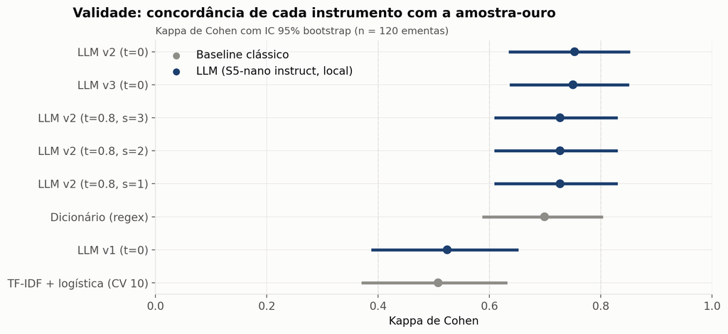

## Três leituras da tabela

1. **O prompt importa:** o melhor LLM (LLM v2 (t=0), kappa 0,75) supera a versão sem definições (v1, kappa 0,52)
2. **LLM × dicionário:** kappa 0,75 × 0,70, com **intervalos sobrepostos**: com 120 ementas, não há evidência de diferença. E o dicionário viu a prova
3. **LLM × TF-IDF:** o modelo clássico (0,51) precisaria de muito mais exemplos rotulados

## Onde o instrumento erra

```python
erro = aval[aval["instrumento"] == melhor]
pd.crosstab(pd.Categorical(erro["categoria"], CATEGORIAS),
            pd.Categorical(erro["categoria_llm"], CATEGORIAS),
            rownames=["humano"], colnames=["llm"], dropna=False)
```

| llm humano | PUNIR | REGULAR | PROMOVER | OUTRO |
| --- | --- | --- | --- | --- |
| PUNIR | 22 | 0 | 0 | 0 |
| REGULAR | 4 | 61 | 4 | 0 |
| PROMOVER | 0 | 2 | 13 | 1 |
| OUTRO | 0 | 5 | 2 | 6 |

```python
(erro.groupby(["categoria", "categoria_llm"]).size()
   .rename("n").reset_index()
   .rename(columns={"categoria": "humano",
                    "categoria_llm": "llm"})
   .query("humano != llm")
   .sort_values("n", ascending=False)
   .set_index("humano"))
```

| humano | llm | n |
| --- | --- | --- |
| OUTRO | REGULAR | 5 |
| REGULAR | PROMOVER | 4 |
| REGULAR | PUNIR | 4 |
| OUTRO | PROMOVER | 2 |
| PROMOVER | REGULAR | 2 |
| PROMOVER | OUTRO | 1 |

Erros não são iguais: confundir REGULAR com PUNIR **infla** a proporção punitiva que vamos estimar; confundir REGULAR com PROMOVER não a afeta.

## Matriz de confusão: a figura

```python
conf = pd.crosstab(pd.Categorical(erro["categoria"], CATEGORIAS),
                   pd.Categorical(erro["categoria_llm"], CATEGORIAS), dropna=False)
prop = conf.div(conf.sum(axis=1), axis=0)
azul = plt.matplotlib.colors.LinearSegmentedColormap.from_list("azul", ["#eef4fc", AZUIS[2]])
fig, ax = plt.subplots(figsize=(8, 4.4))
im = ax.imshow(prop.values, cmap=azul, vmin=0, vmax=1)
for i in range(4):
    for j in range(4):
        ax.text(j, i, conf.values[i, j], ha="center", va="center", fontsize=13,
                color="white" if prop.values[i, j] > .5 else TINTA)
ax.set_xticks(range(4), CATEGORIAS); ax.set_yticks(range(4), CATEGORIAS); ax.grid(False)
ax.set_xlabel("Rótulo do LLM"); ax.set_ylabel("Rótulo humano")
fig.colorbar(im, ax=ax, format=pct, label="% da linha")
fig.suptitle(f"Onde o instrumento erra: {melhor}", x=.01, ha="left", fontweight="bold")
ax.set_title("Linhas: codificação humana · Colunas: LLM · Cor: % da linha",
             fontsize=10, fontweight="normal", color=TINTA2)
plt.show()
```

## Matriz de confusão: a figura

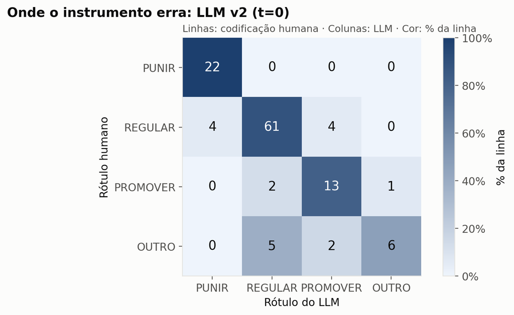

## As ementas que o LLM errou

```python
(erro[erro["categoria"] != erro["categoria_llm"]]
 .merge(corpus[["doc_id", "ementa"]], on="doc_id")
 .assign(ementa=lambda x: x["ementa"].map(lambda s: textwrap.shorten(s, 95, placeholder="...")))
 .rename(columns={"categoria": "humano", "categoria_llm": "llm"})
 .set_index("doc_id")[["humano", "llm", "ementa"]]
 .head(8))
```

| doc_id | humano | llm | ementa |
| --- | --- | --- | --- |
| doc0013 | REGULAR | PUNIR | Altera a Lei nº 9.504, de 30 de setembro de 1997, que estabelece n... |
| doc0020 | REGULAR | PROMOVER | Dispõe sobre a criação do Fundo de Renda Básica, que será utilizad... |
| doc0034 | REGULAR | PUNIR | Altera a Lei nº 9.504, de 30 de setembro de 1997, para dispor sobr... |
| doc0045 | REGULAR | PUNIR | Proíbe o uso de Aplicativos e Programas de Inteligência Artificial... |
| doc0073 | PROMOVER | REGULAR | Dispõe sobre a utilização de ferramentas tecnológicas de inteligên... |
| doc0105 | OUTRO | REGULAR | Altera a Lei nº 9.610, de 19 de fevereiro de 1998 (Lei de Direitos... |
| doc0106 | PROMOVER | OUTRO | Altera a Política Nacional de Busca de Pessoas Desaparecidas incor... |
| doc0169 | REGULAR | PROMOVER | Dispõe sobre o aprimoramento das ações de fomento à escrita humana... |

**Pergunta para a turma:** em quais destes o LLM tem razão e a referência deveria ser revista?

## Viés diferencial: a ideia

Acurácia alta **na média** não garante comparações válidas **entre grupos**.

- Se o LLM erra mais nas ementas de um campo político, qualquer comparação **entre campos** feita com seus rótulos estará enviesada
- Isso é relevante porque o **viés político** de LLMs está documentado (Motoki et al., 2024; Rozado, 2024)
- O que medir por grupo: **acurácia** e, principalmente, o **viés na quantidade que vamos estimar** (proporção PUNIR do LLM − do humano)

## Viés por campo político

```python
dif = erro.merge(corpus[["doc_id", "campo", "casa"]], on="doc_id")
dif = dif.assign(punir_h=dif["categoria"] == "PUNIR", punir_l=dif["categoria_llm"] == "PUNIR",
                 acerto=dif["categoria"] == dif["categoria_llm"])
vies_campo = (dif[dif["campo"] != "Sem partido/Outro"]
              .groupby("campo")
              .agg(n=("acerto", "size"), acuracia=("acerto", "mean"),
                   prop_punir_humano=("punir_h", "mean"), prop_punir_llm=("punir_l", "mean")))
vies_campo["vies_punir"] = vies_campo["prop_punir_llm"] - vies_campo["prop_punir_humano"]
vies_campo["ep"] = np.sqrt(vies_campo["acuracia"] * (1 - vies_campo["acuracia"]) / vies_campo["n"])
vies_campo["li"] = vies_campo["acuracia"] - 1.96 * vies_campo["ep"]
vies_campo["ls"] = vies_campo["acuracia"] + 1.96 * vies_campo["ep"]
vies_campo.round(3)
```

| campo | n | acuracia | prop_punir_humano | prop_punir_llm | vies_punir | ep | li | ls |
| --- | --- | --- | --- | --- | --- | --- | --- | --- |
| Centro | 31 | 0.806 | 0.161 | 0.194 | 0.032 | 0.071 | 0.667 | 0.946 |
| Direita | 52 | 0.827 | 0.154 | 0.192 | 0.038 | 0.052 | 0.724 | 0.930 |
| Esquerda | 33 | 0.909 | 0.182 | 0.212 | 0.030 | 0.050 | 0.811 | 1.007 |

## Viés diferencial: a figura

```python
v = vies_campo.sort_values("acuracia")
fig, ax = plt.subplots(figsize=(10, 4.2))
ax.hlines(v.index, v["li"].clip(0), v["ls"].clip(upper=1), color=AZUIS[2], lw=3)
ax.scatter(v["acuracia"], v.index, color=AZUIS[2], s=60, zorder=3)
for campo, r in v.iterrows():
    ax.annotate(f"n = {int(r.n)}", (r.acuracia, campo), xytext=(0, 10),
                textcoords="offset points", ha="center", color=TINTA2, fontsize=10)
ax.set_xlim(0, 1); ax.xaxis.set_major_formatter(pct); ax.set_xlabel("Acurácia")
ax.set_title("O acerto do LLM varia por campo político do autor?")
plt.show()
```

## Viés diferencial: a figura

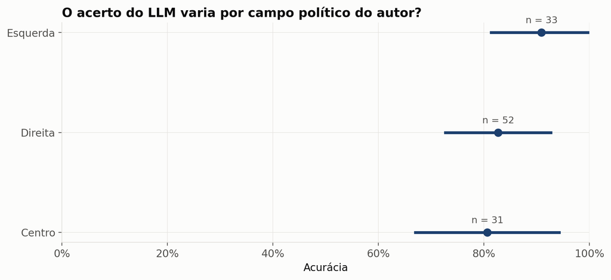

## Um teste formal

```python
from scipy.stats import chi2_contingency
d3 = dif[dif["campo"] != "Sem partido/Outro"]
tab = pd.crosstab(d3["campo"], d3["acerto"])
teste = chi2_contingency(tab, lambda_="log-likelihood")   # razão de verossimilhança
display(tab)
print(f"Desvio (G²) = {teste.statistic:.3f}  gl = {teste.dof}  p = {teste.pvalue:.3f}")
```

| acerto campo | False | True |
| --- | --- | --- |
| Centro | 6 | 25 |
| Direita | 9 | 43 |
| Esquerda | 3 | 30 |

```
Desvio (G²) = 1.642  gl = 2  p = 0.440
```

**Nota**

Não rejeitar não é o mesmo que **descartar** o viés: com 31 a 52 ementas por campo, o teste tem pouco poder. A lição: **com esta amostra-ouro, não é possível descartar viés diferencial**.

## Confiabilidade: o instrumento é estável?

Duas fontes de instabilidade, **sem precisar de rótulo humano**:

- **Teste-reteste:** mesmo prompt (v2), mesma ementa, temperatura 0,8, **três sementes**
- **Sensibilidade ao prompt:** mesmo modelo, temperatura 0, **três redações** (v1, v2, v3)

**Alfa de Krippendorff** (nominal): generaliza o kappa para $k$ codificadores e aceita faltantes

$$\alpha = 1 - \frac{D_o}{D_e} \qquad D_o: \text{discordância observada} \quad D_e: \text{esperada ao acaso}$$

## O alfa num exemplo pequeno

Três codificadores fictícios, seis ementas:

```python
m = pd.DataFrame([["PUNIR",    "PUNIR",   "PUNIR"],
                  ["REGULAR",  "REGULAR", "PROMOVER"],
                  ["REGULAR",  "REGULAR", "REGULAR"],
                  ["OUTRO",    "OUTRO",   None],
                  ["PROMOVER", "REGULAR", "PROMOVER"],
                  ["REGULAR",  "REGULAR", "REGULAR"]])
print(alfa_krippendorff(m))
print(alfa_krippendorff(m.iloc[:, :2]))
```

```
0.6559139784946237
0.7441860465116279
```

`m` é a matriz de rótulos (ementas × codificadores). Dentro de `alfa_krippendorff()`, ela vira a matriz de **coincidências**, que conta pares de rótulos dentro de cada ementa; a diagonal são concordâncias. Sem o terceiro codificador, a concordância muda.

## Teste-reteste: trocar a semente

```python
largo_seed = (llm[(llm["prompt_id"] == "v2") & (llm["temperatura"] > 0)]
              .pivot(index="doc_id", columns="semente", values="categoria_llm")
              .add_prefix("s"))
display(largo_seed.head(4))
alfa_reteste = alfa_krippendorff(largo_seed)
muda_seed = (largo_seed.nunique(axis=1) > 1).mean()
pd.DataFrame([dict(alfa=alfa_reteste, prop_que_muda=muda_seed)])
```

| semente doc_id | s1 | s2 | s3 |
| --- | --- | --- | --- |
| doc0001 | REGULAR | REGULAR | REGULAR |
| doc0002 | REGULAR | REGULAR | REGULAR |
| doc0003 | REGULAR | REGULAR | REGULAR |
| doc0004 | REGULAR | REGULAR | REGULAR |

|  | alfa | prop_que_muda |
| --- | --- | --- |
| 0 | 1.0 | 0.0 |

## Sensibilidade ao prompt: trocar a redação

```python
largo_prompt = (llm[(llm["temperatura"] == 0) & (llm["semente"] == 42)]
                .pivot(index="doc_id", columns="prompt_id", values="categoria_llm"))
alfa_prompt = alfa_krippendorff(largo_prompt)
muda_prompt = (largo_prompt.nunique(axis=1) > 1).mean()
pd.DataFrame(dict(comparacao=["Teste-reteste (v2, t=0,8, 3 sementes)",
                              "Sensibilidade ao prompt (v1, v2, v3; t=0)"],
                  alfa=[alfa_reteste, alfa_prompt],
                  prop_ementas_que_mudam=[muda_seed, muda_prompt])).set_index("comparacao")
```

| comparacao | alfa | prop_ementas_que_mudam |
| --- | --- | --- |
| Teste-reteste (v2, t=0,8, 3 sementes) | 1.000000 | 0.000000 |
| Sensibilidade ao prompt (v1, v2, v3; t=0) | 0.746254 | 0.233553 |

**Importante**

**O prompt importa muito mais que o acaso:** trocar a semente muda 0% das ementas; trocar o prompt muda 23%.

## Ementas que mudam com o prompt

```python
lp = largo_prompt.reset_index()
(lp[(lp["v1"] != lp["v2"]) | (lp["v2"] != lp["v3"])]
 .merge(corpus[["doc_id", "ementa"]], on="doc_id")
 .merge(ref[["doc_id", "categoria"]].rename(columns={"categoria": "ref"}), on="doc_id")
 .assign(ementa=lambda x: x["ementa"].map(lambda s: textwrap.shorten(s, 70, placeholder="...")))
 .set_index("doc_id")[["v1", "v2", "v3", "ref", "ementa"]]
 .head(8))
```

| doc_id | v1 | v2 | v3 | ref | ementa |
| --- | --- | --- | --- | --- | --- |
| doc0004 | OUTRO | REGULAR | OUTRO | REGULAR | Dispõe sobre o uso da Inteligência Artificial. |
| doc0007 | REGULAR | PROMOVER | PROMOVER | REGULAR | Dispõe sobre a compatibilização dos sistemas de Inteligência... |
| doc0009 | PROMOVER | PROMOVER | OUTRO | OUTRO | Institui a Política Nacional de Educação Digital; altera as Leis... |
| doc0010 | REGULAR | OUTRO | OUTRO | OUTRO | Dispõe sobre a reforma da Lei nº 9.784/99 (Lei de Processo... |
| doc0012 | REGULAR | PROMOVER | PROMOVER | PROMOVER | Estabelece procedimentos a serem adotados pela União em regime de... |
| doc0013 | REGULAR | PUNIR | PUNIR | REGULAR | Altera a Lei nº 9.504, de 30 de setembro de 1997, que estabelece... |
| doc0014 | REGULAR | REGULAR | PROMOVER | REGULAR | Dispõe sobre normas gerais para a pesquisa, o desenvolvimento e a... |
| doc0018 | OUTRO | REGULAR | OUTRO | REGULAR | Dispõe sobre o uso da Inteligência Artificial. |

## A medida agregada também muda

```python
dist_all = (llm[(llm["temperatura"] == 0) & (llm["semente"] == 42)]
            .groupby("prompt_id")["categoria_llm"].value_counts(normalize=True)
            .unstack(fill_value=0))
dist_all.loc["Referência\nhumana"] = ref["categoria"].value_counts(normalize=True)
dist_all = dist_all.fillna(0)[CATEGORIAS]

cores = [AZUIS[0], AZUIS[1], AZUIS[2], CINZA]          # v1, v2, v3, referência
fig, axs = plt.subplots(1, 4, figsize=(10, 4.5), sharey=True, sharex=True)
for ax, c in zip(axs, CATEGORIAS):
    ax.barh(dist_all.index[::-1], dist_all[c].values[::-1], color=cores[::-1], height=.7)
    ax.set_title(c, fontsize=11)
    ax.set_xticks([0, .3, .6]); ax.set_xlim(0, .7); ax.xaxis.set_major_formatter(pct)
    ax.grid(axis="y", visible=False)
fig.suptitle("Mesmo modelo, mesmos textos, prompts diferentes: medidas diferentes",
             x=.01, ha="left", fontweight="bold")
fig.tight_layout(); plt.show()
```

## A medida agregada também muda

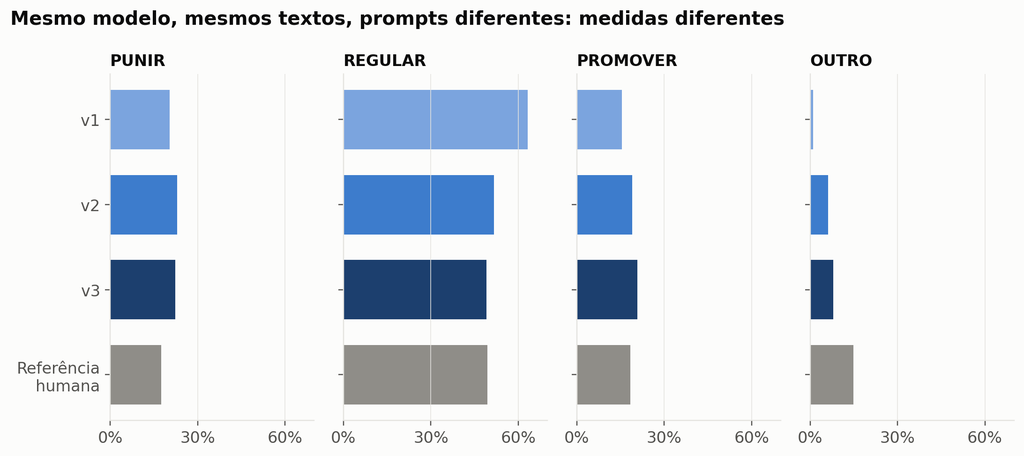

## A variável eleitoral

```python
ele = (llm[(llm["temperatura"] == 0) & (llm["semente"] == 42)]
       .merge(ouro[["doc_id", "eleitoral"]], on="doc_id"))
ele["eleitoral_llm"] = ele["eleitoral_llm"].astype("boolean")
pd.DataFrame([dict(prompt_id=p,
                   eleitorais_humano=int(g["eleitoral"].sum()),
                   eleitorais_llm=int(g["eleitoral_llm"].sum()),
                   sensibilidade=g.loc[g["eleitoral"] == 1, "eleitoral_llm"].mean(),
                   especificidade=(~g.loc[g["eleitoral"] == 0, "eleitoral_llm"]).mean())
              for p, g in ele.groupby("prompt_id")]).set_index("prompt_id")
```

| prompt_id | eleitorais_humano | eleitorais_llm | sensibilidade | especificidade |
| --- | --- | --- | --- | --- |
| v1 | 8 | 8 | 1.0 | 1.0 |
| v2 | 8 | 8 | 1.0 | 1.0 |
| v3 | 8 | 8 | 1.0 | 1.0 |

Variável **rara**: acurácia não informa quase nada.

**Sensibilidade** (dos eleitorais, quantos o LLM achou?) e

**especificidade** (dos não eleitorais, quantos descartou?).

Com tão poucos casos eleitorais, a sensibilidade é muito imprecisa.

## Humano × humano: a comparação que falta

Quando a referência for revisada por **dois codificadores humanos**, este trecho calcula o alfa entre eles:

```python
from pathlib import Path
arqs = sorted(Path("material_apoio/respostas").glob("*.csv"))
resp = pd.concat([pd.read_csv(a).assign(codificador=a.stem) for a in arqs])
resp["categoria"] = resp["categoria"].str.strip().str.upper()
m = resp.pivot(index="doc_id", columns="codificador", values="categoria")
alfa_krippendorff(m)     # alfa entre os codificadores
```

**A comparação mais honesta**

O LLM concorda com a referência **tanto quanto os humanos concordam entre si**? Neste material a referência é de outra IA, então essa resposta ainda **não existe**.

**Pergunta para a turma**

O kappa do S5-nano contra a referência é alto ou baixo? **Comparado a quê?**

## Síntese da validação

**Executamos**

- métricas e IC bootstrap de 8 instrumentos
- matriz de confusão e erros
- viés por campo e teste de razão de verossimilhança
- alfa entre sementes e entre prompts

**O que sabemos do instrumento**

- concordância **substancial** com a referência
- **estável** entre sementes
- **sensível ao prompt**
- viés diferencial **não descartado**

→ bom, mas **imperfeito**. Como usá-lo sem esconder isso?

# 6 · Inferência com rótulos imperfeitos

## O que vamos executar neste bloco

1. Montar, para cada ementa, o rótulo do **LLM** ($f$) e o **humano** ($y$, só na amostra-ouro)
2. Quatro estimadores da proporção PUNIR: **só humanos**, **ingênuo**, **PPI** e **PPI++**
3. Conferir quem acerta o valor da referência completa
4. Uma **simulação**: 1.000 amostras-ouro para cada tamanho, e a **cobertura** dos ICs
5. A mesma pergunta **por campo político**

## O problema

Queremos $\theta$ = proporção de projetos **PUNIR**. Temos:

- a **amostra-ouro**: $n$ = 120 ementas com rótulo humano $Y_j$ **e** do LLM $f(X_j)$
- as outras $N$ = 184 ementas, só com o rótulo do LLM $f(X_i)$

“Humano” = o rótulo de referência. Neste material ele ainda é preliminar e veio de outra IA; o método é o mesmo quando a referência for revisada por humanos.

**Só humanos**
$$\hat\theta_H = \bar Y_n$$
sem viés, mas **impreciso**

**Ingênuo**
$$\hat\theta_{LLM} = \bar f_{N+n}$$
preciso, mas **enviesado** pelo erro do LLM

## Montando $y$ e $f$

```python
PROMPT = re.search(r"v\d", melhor).group()
t0 = llm[(llm["prompt_id"] == PROMPT) & (llm["temperatura"] == 0) & (llm["semente"] == 42)]
dados = (corpus[["doc_id", "ano", "campo", "casa"]]
         .merge(t0[["doc_id", "categoria_llm"]], on="doc_id", how="left")
         .merge(ref[["doc_id", "categoria"]].rename(columns={"categoria": "categoria_ref"}),
                on="doc_id", how="left"))
dados["na_ouro"] = dados["doc_id"].isin(ouro["doc_id"])
dados["f"] = (dados["categoria_llm"] == "PUNIR").astype(int)                       # LLM: 0/1
dados["y"] = (dados["categoria_ref"] == "PUNIR").astype("Int64").where(dados["na_ouro"])  # humano: 0/1 ou NA
display(dados[["doc_id", "campo", "categoria_llm", "na_ouro", "f", "y"]].head(6))
lab, unl = dados[dados["na_ouro"]], dados[~dados["na_ouro"]]
print(dict(n=len(lab), N=len(unl)))
```

|  | doc_id | campo | categoria_llm | na_ouro | f | y |
| --- | --- | --- | --- | --- | --- | --- |
| 0 | doc0001 | Direita | REGULAR | True | 0 | 0 |
| 1 | doc0002 | Direita | REGULAR | False | 0 | <NA> |
| 2 | doc0003 | Direita | REGULAR | True | 0 | 0 |
| 3 | doc0004 | Centro | REGULAR | True | 0 | 0 |
| 4 | doc0005 | Esquerda | REGULAR | False | 0 | <NA> |
| 5 | doc0006 | Sem partido/Outro | REGULAR | False | 0 | <NA> |

```
{'n': 120, 'N': 184}
```

## O “valor verdadeiro” (só porque é didático)

```python
verdade = (ref["categoria"] == "PUNIR").mean()
print(verdade)
```

```
0.17434210526315788
```

**Nota**

Este corpus tem referência para **todas** as 304 ementas, então conhecemos $\theta$ = 17,4%. Numa pesquisa real, **não** conhecemos: por isso precisamos de estimadores com IC honesto. Aqui, podemos **conferir** quem acerta.

## (a) Só humanos

```python
def est_humano(y_n):
    """(a) Só humanos: sem viés, mas com pouca precisão."""
    y_n = np.asarray(y_n, float)
    return ic_normal(y_n.mean(), y_n.std(ddof=1) / np.sqrt(len(y_n)))
```

```python
pd.DataFrame([est_humano(lab["y"])])
```

|  | estimativa | ep | li | ls |
| --- | --- | --- | --- | --- |
| 0 | 0.183333 | 0.035471 | 0.113812 | 0.252855 |

Média da amostra-ouro, com erro-padrão $\sqrt{\hat p(1 - \hat p)/n}$. Desperdiça a informação das outras 184 ementas.

## (b) Ingênuo: o LLM como verdade

```python
pd.DataFrame([est_ingenuo(np.concatenate([lab["f"], unl["f"]]))])
```

|  | estimativa | ep | li | ls |
| --- | --- | --- | --- | --- |
| 0 | 0.230263 | 0.024186 | 0.18286 | 0.277667 |

Por que ele erra? Na amostra-ouro, temos **os dois** rótulos:

```python
display(pd.DataFrame([dict(LLM=lab["f"].mean(), humano=lab["y"].mean(),
                            vies_estimado=lab["f"].mean() - lab["y"].mean())]))
pd.crosstab(lab["y"], lab["f"], rownames=["humano"], colnames=["llm"])
```

|  | LLM | humano | vies_estimado |
| --- | --- | --- | --- |
| 0 | 0.216667 | 0.183333 | 0.033333 |

| llm humano | 0 | 1 |
| --- | --- | --- |
| 0 | 94 | 4 |
| 1 | 0 | 22 |

O LLM marca PUNIR em ementas que o humano não marca: os **falsos positivos** inflam a proporção. E o IC do ingênuo **ignora** esse erro.

## (c) *Prediction-Powered Inference*

Use a amostra-ouro para **medir o viés do LLM** e subtraia (Angelopoulos et al., *Science*, 2023):

$$\hat\theta_{PP} = \underbrace{\frac{1}{N}\sum_{i=1}^{N} f(X_i)}_{\text{LLM no não rotulado}} \; - \; \underbrace{\frac{1}{n}\sum_{j=1}^{n}\big(f(X_j) - Y_j\big)}_{\text{viés do LLM medido na amostra-ouro (retificador)}}$$

$$\widehat{\text{Var}}(\hat\theta_{PP}) = \frac{\hat\sigma^2_{f}}{N} + \frac{\hat\sigma^2_{f-Y}}{n}$$

- **Nenhuma hipótese** sobre a qualidade do LLM: um LLM ruim gera retificador com variância alta → **IC largo**, não **IC errado**

## PPI em cinco linhas

```python
def est_ppi(y_n, f_n, f_N):
    """(c) Prediction-Powered Inference (Angelopoulos et al., 2023, Science)."""
    y_n, f_n, f_N = (np.asarray(x, float) for x in (y_n, f_n, f_N))
    ret = f_n - y_n
    est = f_N.mean() - ret.mean()
    ep = np.sqrt(f_N.var(ddof=1) / len(f_N) + ret.var(ddof=1) / len(y_n))
    return ic_normal(est, ep)
```

```python
pd.DataFrame([est_ppi(lab["y"], lab["f"], unl["f"])])
```

|  | estimativa | ep | li | ls |
| --- | --- | --- | --- | --- |
| 0 | 0.205797 | 0.035567 | 0.136087 | 0.275507 |

## PPI passo a passo

```python
retificador = lab["f"] - lab["y"]
pd.DataFrame([dict(media_f_N  = unl["f"].mean(),
                   vies       = retificador.mean(),
                   estimativa = unl["f"].mean() - retificador.mean(),
                   ep         = np.sqrt(unl["f"].var() / len(unl) + retificador.var() / len(lab)))])
```

|  | media_f_N | vies | estimativa | ep |
| --- | --- | --- | --- | --- |
| 0 | 0.23913 | 0.033333 | 0.205797 | 0.035567 |

O viés estimado é subtraído; o erro-padrão soma a incerteza do LLM no não rotulado e a do retificador na amostra-ouro.

## (d) PPI++: quanto confiar no LLM?

PPI++ (Angelopoulos, Duchi & Zrnic, 2023) pondera o LLM por $\lambda \in [0, 1]$, escolhido para **minimizar a variância**:

$$\hat\theta_{PP}^{\lambda} = \bar Y_n + \lambda\big(\bar f_N - \bar f_n\big), \qquad
\hat\lambda = \frac{\widehat{\text{Cov}}(Y, f)}{(1 + n/N)\,\widehat{\text{Var}}(f)}$$

- LLM inútil → $\hat\lambda \to 0$: volta a ser o “só humanos”
- LLM muito bom → $\hat\lambda \to 1$: aproxima-se do PPI

## PPI++ em Python

```python
def est_ppi_plus(y_n, f_n, f_N):
    """(d) PPI++ (Angelopoulos, Duchi & Zrnic, 2023): ajusta o peso λ do LLM."""
    y_n, f_n, f_N = (np.asarray(x, float) for x in (y_n, f_n, f_N))
    n, N = len(y_n), len(f_N)
    f_todos = np.concatenate([f_n, f_N])
    lam = np.cov(y_n, f_n, ddof=1)[0, 1] / ((1 + n / N) * f_todos.var(ddof=1))
    lam = float(min(max(lam, 0), 1))
    est = y_n.mean() + lam * (f_N.mean() - f_n.mean())
    ep = np.sqrt((y_n - lam * f_n).var(ddof=1) / n + lam ** 2 * f_N.var(ddof=1) / N)
    return {**ic_normal(est, ep), "lambda": lam}
```

```python
pd.DataFrame([est_ppi_plus(lab["y"], lab["f"], unl["f"])])
```

|  | estimativa | ep | li | ls | lambda |
| --- | --- | --- | --- | --- | --- |
| 0 | 0.194406 | 0.025623 | 0.144185 | 0.244627 | 0.492911 |

## Os quatro estimadores

```python
est = compara_estimadores(lab["y"], lab["f"], unl["f"])
est = est.assign(largura=est["ls"] - est["li"],
                 cobre_verdade=(est["li"] <= verdade) & (verdade <= est["ls"]))
est.set_index("estimador").round(3)
```

| estimador | estimativa | ep | li | ls | lambda | largura | cobre_verdade |
| --- | --- | --- | --- | --- | --- | --- | --- |
| Só humanos (amostra-ouro) | 0.183 | 0.035 | 0.114 | 0.253 | NaN | 0.139 | True |
| Ingênuo (LLM = verdade) | 0.230 | 0.024 | 0.183 | 0.278 | NaN | 0.095 | False |
| PPI | 0.206 | 0.036 | 0.136 | 0.276 | NaN | 0.139 | True |
| PPI++ | 0.194 | 0.026 | 0.144 | 0.245 | 0.493 | 0.100 | True |

Valor na referência completa: **17,4%**. Conferência com o pipeline: estimativas idênticas às de resultados/python/tabelas/estimativas_punir.csv.

## A figura

```python
e = est.iloc[::-1]
cores = e["estimador"].map(COR_EST)
fig, ax = plt.subplots(figsize=(10, 4.2))
ax.axvline(verdade, color=CINZA_ESCURO, lw=1.2, ls="--")
ax.hlines(e["estimador"], e["li"], e["ls"], color=cores, lw=3)
ax.scatter(e["estimativa"], e["estimador"], color=cores, s=60, zorder=3)
ax.xaxis.set_major_formatter(pct)
fig.suptitle("Que proporção dos projetos sobre IA quer PUNIR?", x=.01, ha="left", fontweight="bold")
ax.set_title("IC 95% · linha tracejada: valor na referência completa",
             fontsize=10, fontweight="normal", color=TINTA2)
plt.show()
```

## A figura

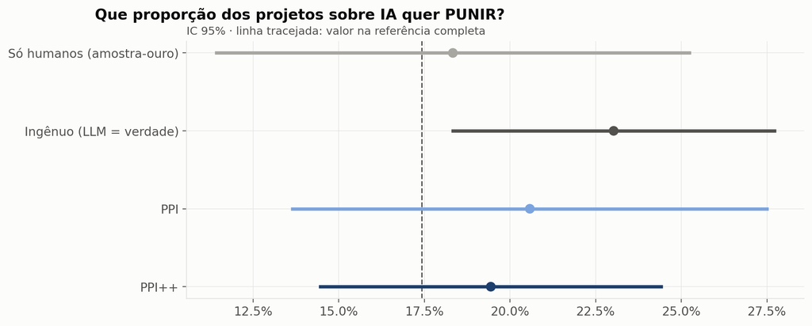

## Um resultado pode ser sorte

Um único sorteio da amostra-ouro não diz se o método é bom. Então:

1. Sorteie uma amostra-ouro de tamanho $n$ (30, 60 ou 120)
2. Calcule os quatro estimadores e seus ICs
3. Verifique se cada IC **contém** o valor verdadeiro
4. Repita **1.000 vezes**

**Cobertura** = proporção de repetições em que o IC contém a verdade. Um bom IC de 95% acerta em ~95%.

## A simulação em Python

```python
import time
def simula(n_ouro, B=1000, semente=1):
    rng = np.random.default_rng(semente)
    y_todos = (dados["categoria_ref"] == "PUNIR").astype(int).values
    f_todos = dados["f"].values
    res = []
    for _ in range(B):
        idx = rng.choice(len(dados), n_ouro, replace=False)             # nova amostra-ouro
        resto = np.setdiff1d(np.arange(len(dados)), idx)
        res.append(compara_estimadores(y_todos[idx], f_todos[idx], f_todos[resto]))
    r = pd.concat(res)
    r = r.assign(cobre=(r["li"] <= verdade) & (verdade <= r["ls"]), largura=r["ls"] - r["li"])
    return (r.groupby("estimador", sort=False)
             .agg(cobertura=("cobre", "mean"), largura_media=("largura", "mean"),
                  vies=("estimativa", lambda x: x.mean() - verdade))
             .reset_index().assign(n_ouro=n_ouro))
inicio = time.time()
sim = pd.concat([simula(n) for n in (30, 60, 120)], ignore_index=True)
tempo = time.time() - inicio
print(round(tempo, 1))
```

```
0.9
```

## Cobertura e largura

```python
(sim[["n_ouro", "estimador", "cobertura", "largura_media", "vies"]]
 .sort_values("n_ouro", kind="stable").set_index(["n_ouro", "estimador"]).round(3))
```

| n_ouro | estimador | cobertura | largura_media | vies |
| --- | --- | --- | --- | --- |
| 30 | Só humanos (amostra-ouro) | 0.897 | 0.267 | -0.001 |
|  | Ingênuo (LLM = verdade) | 0.000 | 0.095 | 0.056 |
|  | PPI | 0.846 | 0.188 | -0.002 |
|  | PPI++ | 0.869 | 0.160 | -0.014 |
| 60 | Só humanos (amostra-ouro) | 0.971 | 0.192 | 0.001 |
|  | Ingênuo (LLM = verdade) | 0.000 | 0.095 | 0.056 |
|  | PPI | 0.974 | 0.157 | -0.001 |
|  | PPI++ | 0.970 | 0.125 | -0.005 |
| 120 | Só humanos (amostra-ouro) | 0.989 | 0.136 | 0.001 |
|  | Ingênuo (LLM = verdade) | 0.000 | 0.095 | 0.056 |
|  | PPI | 0.988 | 0.147 | -0.000 |
|  | PPI++ | 1.000 | 0.103 | -0.002 |

## O IC ingênuo engana

```python
fig, ax = plt.subplots(figsize=(10, 4.6))
ax.axhline(.95, color=TINTA2, ls="--")
for nome, dd in sim.groupby("estimador", sort=False):
    ax.plot(dd["n_ouro"].astype(str), dd["cobertura"], "o-", color=COR_EST[nome], lw=2, label=nome)
ax.set_ylim(0, 1.02); ax.yaxis.set_major_formatter(pct)
ax.set_xlabel("Tamanho da amostra-ouro"); ax.set_ylabel("Cobertura")
ax.set_title("Com que frequência o IC de 95% contém a verdade?")
ax.legend(frameon=False, loc="center right")
plt.show()
```

## O IC ingênuo engana

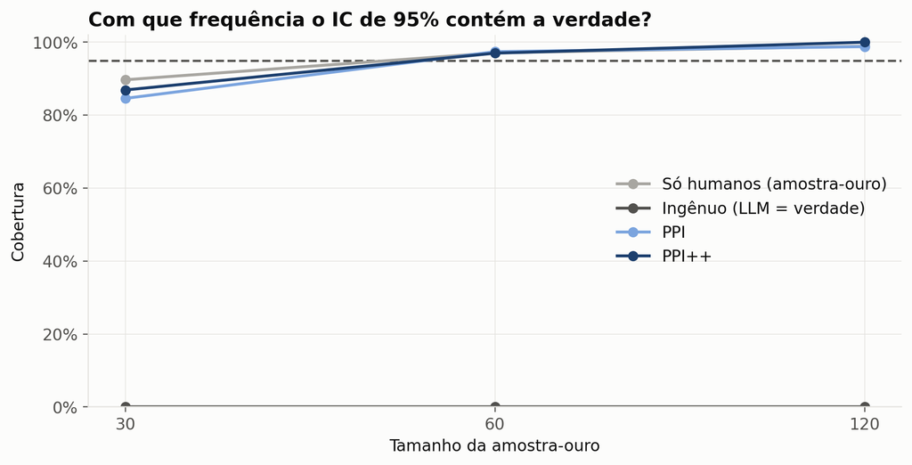

## O preço da honestidade

```python
fig, ax = plt.subplots(figsize=(10, 4.6))
for nome, dd in sim.groupby("estimador", sort=False):
    ax.plot(dd["n_ouro"].astype(str), dd["largura_media"], "o-", color=COR_EST[nome], lw=2, label=nome)
ax.yaxis.set_major_formatter(pct)
ax.set_xlabel("Tamanho da amostra-ouro"); ax.set_ylabel("Largura média")
fig.suptitle("Largura média do IC de 95%", x=.01, ha="left", fontweight="bold")
ax.set_title("O ingênuo é estreito porque ignora o erro do LLM",
             fontsize=10, fontweight="normal", color=TINTA2)
ax.legend(frameon=False, loc="upper right")
plt.show()
```

## O preço da honestidade

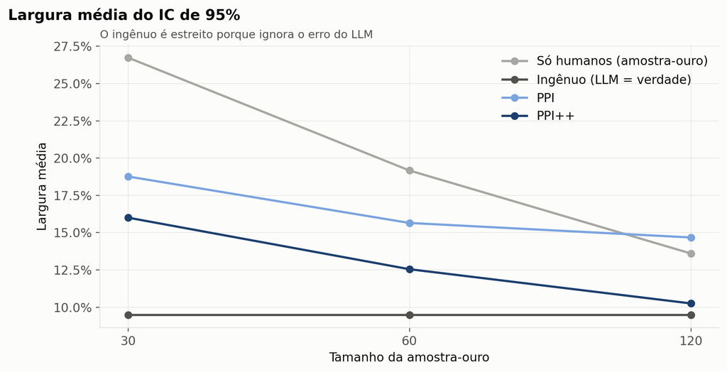

## E entre campos políticos?

```python
linhas = []
for campo, d in dados[dados["campo"].isin(["Esquerda", "Centro", "Direita"])].groupby("campo"):
    l, u = d[d["na_ouro"]], d[~d["na_ouro"]]
    linhas.append(compara_estimadores(l["y"], l["f"], u["f"])
                  .assign(campo=campo, n_ouro=len(l), verdade=(d["categoria_ref"] == "PUNIR").mean()))
por_campo = pd.concat(linhas, ignore_index=True)
por_campo.set_index(["campo", "estimador"])[["n_ouro", "estimativa", "li", "ls", "verdade"]].round(3)
```

| campo | estimador | n_ouro | estimativa | li | ls | verdade |
| --- | --- | --- | --- | --- | --- | --- |
| Centro | Só humanos (amostra-ouro) | 31 | 0.161 | 0.030 | 0.293 | 0.131 |
|  | Ingênuo (LLM = verdade) | 31 | 0.230 | 0.123 | 0.336 | 0.131 |
|  | PPI | 31 | 0.234 | 0.061 | 0.407 | 0.131 |
|  | PPI++ | 31 | 0.188 | 0.082 | 0.294 | 0.131 |
| Direita | Só humanos (amostra-ouro) | 52 | 0.154 | 0.055 | 0.253 | 0.174 |
|  | Ingênuo (LLM = verdade) | 52 | 0.219 | 0.154 | 0.285 | 0.174 |
|  | PPI | 52 | 0.195 | 0.097 | 0.292 | 0.174 |
|  | PPI++ | 52 | 0.174 | 0.103 | 0.245 | 0.174 |
| Esquerda | Só humanos (amostra-ouro) | 33 | 0.182 | 0.048 | 0.315 | 0.188 |
|  | Ingênuo (LLM = verdade) | 33 | 0.225 | 0.133 | 0.317 | 0.188 |
|  | PPI | 33 | 0.204 | 0.068 | 0.340 | 0.188 |
|  | PPI++ | 33 | 0.193 | 0.096 | 0.290 | 0.188 |

## Por campo: a figura

```python
ests = ["Só humanos (amostra-ouro)", "Ingênuo (LLM = verdade)", "PPI"]
fig, axs = plt.subplots(3, 1, figsize=(10, 4.6), sharex=True)
for ax, campo in zip(axs, ["Centro", "Direita", "Esquerda"]):
    dd = por_campo[por_campo["campo"] == campo].set_index("estimador").loc[ests[::-1]]
    cores = [COR_EST[i] for i in dd.index]
    ax.axvline(dd["verdade"].iloc[0], color=CINZA_ESCURO, lw=1, ls="--")
    ax.hlines(dd.index, dd["li"].clip(0), dd["ls"], color=cores, lw=3)
    ax.scatter(dd["estimativa"], dd.index, color=cores, s=50, zorder=3)
    ax.set_title(campo, fontsize=11)
axs[-1].xaxis.set_major_formatter(pct)
fig.tight_layout(); plt.show()
```

## Por campo: a figura

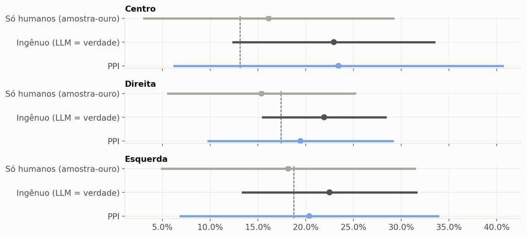

## O que os números dizem

- **O ingênuo superestima** a proporção punitiva (23,0% × 17,4%) e seu IC cobriu a verdade em **0%** das simulações
- **PPI e PPI++ corrigem o viés**: cobertura de 98,8% e 100,0% com $n$ = 120
- **PPI++ é mais estreito** que o “só humanos”: 25% a menos de largura, em média
- Com $n$ = 30, todos ficam abaixo de 95%: amostras-ouro muito pequenas comprometem a aproximação normal
- **Por campo**, 31 a 52 ementas na ouro: intervalos largos e sobrepostos. **Não há evidência** de diferença entre campos

## A resposta substantiva

**Ilustrativa, enquanto a referência for preliminar**

Pelo **PPI++**, cerca de **19%** dos projetos sobre IA no Congresso querem **punir** (IC 95% de 14% a 24%). Cerca de metade **regula** (49% na referência).

E a resposta metodológica: **o LLM ajudou**, mas só porque medimos seu erro e o levamos para dentro do intervalo de confiança.

## Resumo do bloco 6

**Executamos**

- os quatro estimadores, passo a passo
- conferência com a referência completa
- simulação de cobertura (1 s)
- estimativas por campo político

**A lição**

- rótulo de LLM **não é** dado observado
- a amostra-ouro tem **dois papéis**: validar e **corrigir**
- relatar $n$ da amostra-ouro **em cada grupo**

# 7 · Reprodutibilidade (MLOps)

## O que vamos executar neste bloco

1. Listar **o que precisa ser versionado** numa pesquisa com LLM
2. Ler o pipeline declarativo da trilha R (`_targets.R`) e ver como refazer tudo em Python
3. Conferir, no cache, **a identidade do instrumento**: digest dos pesos, versão do Ollama, hash do prompt
4. Medir o *drift* de um modelo local: **repetir** as anotações a temperatura 0
5. Comparar as trilhas **R e Python**

## O que precisa ser versionado?

| Componente | Como versionar | Neste material |
| --- | --- | --- |
| Código | Git | `R/`, `python/` |
| Ambiente | `renv` / `requirements.txt` / Docker | `R/00_pacotes.R`, `requirements.txt`, `sessionInfo.txt` |
| Dados brutos | congelados, com data | `dados/bruto/`, `corpus.csv` (06/11/2026) |
| Instrumento | modelo (digest) + prompt (hash) + parâmetros | `modelos/`, `prompts/` + CHANGELOG |
| Respostas do LLM | cache (é dado, não lixo) | `dados/cache_llm/*.jsonl` |
| Referência humana | arquivo com codificador e revisão | `referencia_completa.csv` |

## Um pipeline declarativo: `_targets.R`

```r
# trilha R: o pipeline do material é escrito com o pacote targets
list(
  tar_target(arq_corpus, "dados/processado/corpus.csv", format = "file"),
  tar_target(arq_prompts, list.files("prompts", "\\.txt$", full.names = TRUE), format = "file",
             cue = tar_cue(mode = "always")),
  tar_target(arq_cache_llm, list.files("dados/cache_llm", "\\.jsonl$", full.names = TRUE),
             format = "file", cue = tar_cue(mode = "always")),
  tar_target(amostra_ouro, roda_script("R/02_amostra_ouro.R", ..., arq_corpus, arq_referencia)),
  tar_target(baselines,    roda_script("R/03_baselines.R", ..., amostra_ouro)),
  tar_target(validacao,    roda_script("R/05_validacao.R", ..., baselines, arq_cache_llm, arq_prompts)),
  tar_target(inferencia,   roda_script("R/06_inferencia.R", ..., validacao))
)
```

Cada etapa declara **de que depende**. Coleta e anotação **não** entram como etapas (são caras e externas): entram como **arquivos versionados**. Em Python, as mesmas etapas são os notebooks `python/02…05_*.ipynb`.

## O grafo, lido pelo `targets`

```r
targets::tar_manifest(fields = c(name, command)) |>
  mutate(command = str_trunc(command, 80))
```

```
#> # A tibble: 11 × 2
#>    name           command
#>    <chr>          <chr>
#>  1 arq_scripts    "list.files(\"R\", \"^0[2-6]_.*\\\\.R$\", full.names = TRUE)"
#>  2 arq_funcoes    "c(\"R/funcoes_medicao.R\", \"R/tema_graficos.R\")"
#>  3 arq_prompts    "list.files(\"prompts\", \"\\\\.txt$\", full.names = TRUE)"
#>  4 arq_corpus     "\"dados/processado/corpus.csv\""
#>  5 arq_referencia "\"dados/anotacoes/referencia_completa.csv\""
#>  6 arq_cache_llm  "list.files(\"dados/cache_llm\", \"\\\\.jsonl$\", full.names = TRUE)"
#>  7 amostra_ouro   "roda_script(\"R/02_amostra_ouro.R\", c(\"dados/anotacoes/amostra_ouro.csv\", \n …
#>  8 baselines      "roda_script(\"R/03_baselines.R\", c(\"resultados/tabelas/baselines.csv\", \n    …
#>  9 validacao      "roda_script(\"R/05_validacao.R\", c(\"resultados/tabelas/validade_instrumentos.c…
#> 10 inferencia     "roda_script(\"R/06_inferencia.R\", c(\"resultados/tabelas/estimativas_punir.csv\…
#> 11 sessao         "{\n     inferencia\n     writeLines(capture.output(sessionInfo()), \"resultados/…
```

## Rodando o pipeline

```r
targets::tar_make()        # roda só o que está desatualizado
targets::tar_outdated()    # editei o prompt v2... o que precisa ser refeito?
targets::tar_visnetwork()  # desenha o grafo (precisa do pacote visNetwork)
```

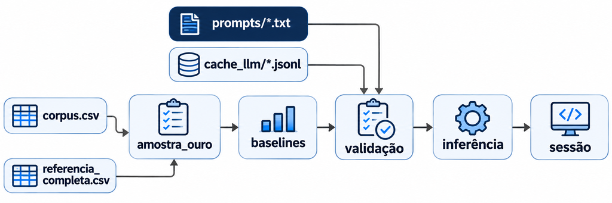

Editou um prompt? `validacao` e `inferencia` ficam desatualizadas; `amostra_ouro` e `baselines`, não.

## Uma armadilha do próprio `targets`

**Encontrada na verificação deste material**

Com `format = "file"` apenas, o `targets` detecta **edições** em arquivos conhecidos, mas **não detecta arquivos novos**: `list.files()` não é reexecutado, porque seu código não mudou. Um prompt v4 ou uma nova execução do LLM passariam **em silêncio**.

**Correção:** `cue = tar_cue(mode = "always")` nas entradas que listam pastas. A lista é refeita sempre; as etapas seguintes só rodam se o conteúdo mudou.

**Lição:** ferramentas de reprodutibilidade **também precisam ser testadas**.

## A identidade do instrumento, no cache

```python
display(llm[["modelo", "modelo_digest", "ollama_versao", "prompt_id", "prompt_sha",
             "temperatura", "semente"]]
        .drop_duplicates().sort_values(["prompt_id", "temperatura", "semente"])
        .reset_index(drop=True))
print(llm["timestamp"].min(), "→", llm["timestamp"].max())
```

|  | modelo | modelo_digest | ollama_versao | prompt_id | prompt_sha | temperatura | semente |
| --- | --- | --- | --- | --- | --- | --- | --- |
| 0 | s5-nano-instruct | 85ec77c8f04e | 0.40.15 | v1 | 5eb0f92ea13d | 0.0 | 42 |
| 1 | s5-nano-instruct | 85ec77c8f04e | 0.40.15 | v2 | c4b5a5ade801 | 0.0 | 42 |
| 2 | s5-nano-instruct | 85ec77c8f04e | 0.40.15 | v2 | c4b5a5ade801 | 0.8 | 1 |
| 3 | s5-nano-instruct | 85ec77c8f04e | 0.40.15 | v2 | c4b5a5ade801 | 0.8 | 2 |
| 4 | s5-nano-instruct | 85ec77c8f04e | 0.40.15 | v2 | c4b5a5ade801 | 0.8 | 3 |
| 5 | s5-nano-instruct | 85ec77c8f04e | 0.40.15 | v3 | 6fdbfaf1d613 | 0.0 | 42 |

```
2026-11-12T02:36:44+00:00 → 2026-11-12T02:48:22+00:00
```

`s5-nano-instruct` é só um **apelido local**: o *digest* identifica os pesos. A versão do Ollama entra porque **o software que executa o modelo também é parte do instrumento**.

## *Drift*: quando o instrumento muda sozinho

- **API comercial** atualiza o modelo → mesmo prompt, **outra medida**
- Defesa: **modelo local com versão fixa**, ou registrar `model_id` + data + respostas brutas
- **Monitorar:** re-anotar periodicamente a amostra-ouro e acompanhar o kappa

E um modelo **local**, com os mesmos pesos, o mesmo prompt e temperatura 0… dá sempre a mesma resposta?

## Repetindo a medição

```python
le_jsonl = lambda a: pd.DataFrame([json.loads(l) for l in open(a, encoding="utf-8") if l.strip()])
colunas = ["doc_id", "categoria_llm", "modelo_digest", "ollama_versao"]
partes = []
for p in ["v1", "v2", "v3"]:
    arq = f"s5-nano-instruct__{p}__t0.0__s42.jsonl"
    a = le_jsonl(f"dados/cache_llm/{arq}")[colunas].set_axis(["doc_id", "antes", "dg_a", "ov_a"], axis=1)
    b = le_jsonl(f"dados/repeticao/{arq}")[colunas].set_axis(["doc_id", "depois", "dg_b", "ov_b"], axis=1)
    partes.append(a.merge(b, on="doc_id").assign(prompt=p))
repet = pd.concat(partes, ignore_index=True)
(repet.assign(mesmo=(repet["dg_a"] == repet["dg_b"]) & (repet["ov_a"] == repet["ov_b"]),
              mudou=repet["antes"] != repet["depois"])
      .groupby("prompt").agg(n=("doc_id", "size"), mesmo_instrumento=("mesmo", "all"),
                             mudaram=("mudou", "sum")))
```

| prompt | n | mesmo_instrumento | mudaram |
| --- | --- | --- | --- |
| v1 | 304 | True | 0 |
| v2 | 304 | True | 3 |
| v3 | 304 | True | 2 |

## Quais mudaram?

```python
(repet[repet["antes"] != repet["depois"]]
 .merge(corpus[["doc_id", "ementa"]], on="doc_id")
 .assign(ementa=lambda x: x["ementa"].map(lambda s: textwrap.shorten(s, 80, placeholder="...")))
 .set_index(["prompt", "doc_id"])[["antes", "depois", "ementa"]])
```

| prompt | doc_id | antes | depois | ementa |
| --- | --- | --- | --- | --- |
| v2 | doc0059 | REGULAR | PUNIR | Institui campanha de prevenção e combate aos crimes digitais contr... |
|  | doc0233 | PUNIR | REGULAR | Dispõe sobre medidas de prevenção, combate e responsabilização rel... |
|  | doc0255 | OUTRO | PROMOVER | Institui o Programa Nacional de Municípios Inteligentes e Sustentá... |
| v3 | doc0267 | PROMOVER | REGULAR | Altera a Lei nº 12.651, de 25 de maio de 2012 (Código Florestal), ... |
|  | doc0272 | PUNIR | REGULAR | Altera a Lei nº 13.105, de 16 de março de 2015, para caracterizar ... |

**Importante**

**Temperatura 0 não garante a mesma resposta**: pequenas diferenças numéricas na GPU trocam a resposta mais provável quando há quase empate. A replicação exata vem do **cache**, não de reexecutar o modelo.

## O ambiente

```python
import platform, sklearn, scipy, matplotlib, requests
display(pd.DataFrame([{"Python": platform.python_version(), "numpy": np.__version__,
                        "pandas": pd.__version__, "scikit-learn": sklearn.__version__,
                        "scipy": scipy.__version__, "matplotlib": matplotlib.__version__,
                        "requests": requests.__version__}]))
print(open("requirements.txt", encoding="utf-8").read())
```

|  | Python | numpy | pandas | scikit-learn | scipy | matplotlib | requests |
| --- | --- | --- | --- | --- | --- | --- | --- |
| 0 | 3.11.5 | 1.26.4 | 2.1.4 | 1.4.2 | 1.11.4 | 3.7.5 | 2.32.3 |

```
# Trilha Python do minicurso (testado com Python 3.11)
pandas>=2.0
numpy>=1.24
requests>=2.31
scikit-learn>=1.3
matplotlib>=3.7
jupyter
# opcional (API comercial):
# openai>=1.40
```

## R e Python: os mesmos números?

```python
comp = (pd.read_csv("resultados/tabelas/estimativas_punir.csv")[["estimador", "estimativa", "li"]]
        .set_axis(["estimador", "R", "R_li"], axis=1)
        .merge(pd.read_csv("resultados/python/tabelas/estimativas_punir.csv")[["estimador", "estimativa", "li"]]
               .set_axis(["estimador", "Python", "Py_li"], axis=1), on="estimador"))
comp.assign(dif=comp["Python"] - comp["R"], dif_li=comp["Py_li"] - comp["R_li"]).set_index("estimador").round(4)
```

| estimador | R | R_li | Python | Py_li | dif | dif_li |
| --- | --- | --- | --- | --- | --- | --- |
| Só humanos (amostra-ouro) | 0.1833 | 0.1138 | 0.1833 | 0.1138 | 0.0 | 0.0 |
| Ingênuo (LLM = verdade) | 0.2303 | 0.1829 | 0.2303 | 0.1829 | 0.0 | 0.0 |
| PPI | 0.2058 | 0.1361 | 0.2058 | 0.1361 | 0.0 | -0.0 |
| PPI++ | 0.1944 | 0.1442 | 0.1944 | 0.1442 | 0.0 | 0.0 |

Mesmas estimativas. Diferenças só no que depende do gerador aleatório (ICs bootstrap, simulação) e no TF-IDF (bloco 3). Até o hash do prompt é calculado igual nas duas linguagens.

## Código gerado por IA

Agentes de programação (Claude Code, Codex e similares) também produzem análises.

**Regra proposta**

**Trate o código gerado por IA como o de um coautor**: revisão, testes, versionamento. Quem publica responde por ele.

- Este material foi produzido com o auxílio do **Claude Opus 5.5** (Anthropic)
- A verificação de ponta a ponta encontrou e corrigiu falhas reais: o `tar_cue`, caches de outro modelo sendo lidos junto, o erro 504 sem *retry*
- Os dois papéis não se confundem: o **S5-nano** é o instrumento estudado; o **Claude** foi o auxiliar na produção

## Checklist para o seu próximo artigo

```python
chk = open("CHECKLIST.md", encoding="utf-8").read().splitlines()
sel = [l for l in chk if re.match(r"^## |^- \[ \]", l)]
print("\n".join(textwrap.shorten(l, 110, placeholder="...") for l in sel[0:6] + sel[12:17]))
```

```
## A. Antes de anotar
- [ ] A **pergunta de pesquisa** e o **conceito** a medir estão definidos sem depender do LLM?
- [ ] Existe um **livro de códigos** escrito, com definições, regras de decisão e exemplos?
- [ ] O livro de códigos foi testado com **codificadores humanos** e a concordância entre eles foi medida...
- [ ] A **amostra-ouro** é **aleatória** e de tamanho justificado (custo × precisão)?
- [ ] Há um **baseline barato** (dicionário, modelo clássico) para comparar?
- [ ] **Falhas de formato** contadas e tratadas de forma explícita (não descartadas em silêncio).
- [ ] Dados sensíveis? Preferir **modelo local**; checar termos de uso da API.
## C. Validação
- [ ] **Validade**: acurácia, F1 macro e kappa contra a amostra-ouro, **com intervalo de confiança**.
- [ ] **Matriz de confusão** inspecionada: em quais categorias o modelo erra?
```

## Resumo do bloco 7

**Executamos**

- leitura do pipeline (`_targets.R`, trilha R)
- identidade do instrumento no cache
- repetição a t = 0 (*drift* local)
- comparação R × Python

**A lição**

- versionar **instrumento** e **respostas**, não só código
- o cache é o que permite replicar
- ferramentas de reprodutibilidade também falham: **teste-as**

# 8 · Ética, limites e debate

## IA na política brasileira em 2026

### Eleições (TSE)

- Res. 23.755/2026: **rotulagem** de conteúdo sintético
- **Deepfakes** proibidos, mesmo com autorização
- Vedação de novos conteúdos sintéticos **72h antes / 24h depois** da votação
- IA não pode **recomendar voto**

## O que o nosso corpus diz sobre eleições

```python
d = corpus.merge(ref[["doc_id", "categoria", "eleitoral"]], on="doc_id", how="left")
pd.crosstab(np.where(d["ano_eleitoral"], "ano eleitoral", "ano não eleitoral"),
            np.where(d["eleitoral"] == 1, "tema eleitoral", "outro tema"),
            rownames=["ano_eleitoral"], colnames=[""])
```

| ano_eleitoral | outro tema | tema eleitoral |
| --- | --- | --- |
| ano eleitoral | 172 | 8 |
| ano não eleitoral | 119 | 5 |

Referência preliminar. Para uma afirmação sobre o Congresso, o mesmo cuidado do bloco 6: rótulo do LLM + amostra-ouro + PPI, e não contagem ingênua.

## Para debater

1. Se um LLM classifica 304 ementas em poucos minutos, ainda precisamos de codificadores humanos? **Para quê, exatamente?**
2. Modelo **local** (reprodutível) com kappa menor × API **comercial** com kappa maior?
3. O **viés político** dos LLMs (Motoki et al., 2024) pode contaminar comparações entre campos? Como testar com o que fizemos hoje?
4. Rotulagem obrigatória de conteúdo sintético é **verificável**? Quem audita o detector, e com que amostra-ouro?

## Quando **não** usar um LLM

- O conceito não tem **definição operacional** clara (o LLM vai inventar uma)
- Não há como montar uma **amostra-ouro** (então não há como validar nem corrigir)
- O erro do modelo é **correlacionado** com a variável explicativa e não pode ser corrigido
- Poucos documentos: codificar à mão é mais barato e mais confiável
- Os dados não podem sair da instituição e não há modelo local adequado

## O que fizemos em código

| Bloco | Funções executadas | Saída principal |
| --- | --- | --- |
| 1 · Dados | `req_json`, `camara_partido_na_data`, `extrai_partido_senado`, `limpa_ementa` | `corpus.csv` |
| 2 · Codificação | sorteio com semente, `carrega_ouro` | amostra-ouro de 120 |
| 3 · Baselines | `classifica_dicionario`, `kappa_cohen`, `LogisticRegressionCV` | régua sem LLM |
| 4 · LLM | `chama_ollama`, `extrai_rotulo`, `anota`, `carrega_llm` | cache com 6 execuções |
| 5 · Validação | `boot_ic`, `resumo_metricas`, `alfa_krippendorff`, `chi2_contingency` | validade, viés, confiabilidade |
| 6 · Inferência | `est_humano`, `est_ingenuo`, `est_ppi`, `est_ppi_plus`, `simula` | proporção PUNIR com IC honesto |
| 7 · Reprodutibilidade | `_targets.R` (trilha R), comparação de caches | *drift* e replicação |

## Mensagem final

**Importante**

A IA amplia as formas de responder,  
mas **não substitui** a boa pergunta, o desenho de pesquisa e a **validação estatística**.

- **Material completo:** Python + dados + cache do LLM

**Jodavid Ferreira** · jodavid.ferreira@ufpe.br · jodavid.github.io

## Referências

- Angelopoulos, A. N. et al. (2023). Prediction-powered inference. *Science*, 382(6671).
- Angelopoulos, A. N.; Duchi, J.; Zrnic, T. (2023). PPI++: Efficient prediction-powered inference. *arXiv:2311.01453*.
- Bolognesi, B.; Ribeiro, E.; Codato, A. (2023). A new ideological classification of Brazilian political parties. *Dados*, 66(2).
- Breiman, L. (2001). Statistical modeling: the two cultures. *Statistical Science*, 16(3).
- Chernozhukov, V. et al. (2018). Double/debiased machine learning. *The Econometrics Journal*, 21(1).
- Cohen, J. (1960). A coefficient of agreement for nominal scales. *Educational and Psychological Measurement*, 20(1).
- Egami, N. et al. (2023). Using imperfect surrogates for downstream inference. *NeurIPS*.
- Gilardi, F.; Alizadeh, M.; Kubli, M. (2023). ChatGPT outperforms crowd workers for text-annotation tasks. *PNAS*, 120(30).
- Grimmer, J.; Roberts, M.; Stewart, B. (2022). *Text as Data*. Princeton University Press.
- Krippendorff, K. (2018). *Content Analysis* (4ª ed.). SAGE.
- Landau, W. M. (2021). The targets R package. *JOSS*, 6(57).
- Landis, J. R.; Koch, G. G. (1977). The measurement of observer agreement for categorical data. *Biometrics*, 33(1).
- Motoki, F.; Pinho Neto, V.; Rodrigues, V. (2024). More human than human: measuring ChatGPT political bias. *Public Choice*, 198.
- Tribunal Superior Eleitoral. Resolução nº 23.755, de 2 de março de 2026.
- Vovk, V.; Gammerman, A.; Shafer, G. (2005). *Algorithmic Learning in a Random World*. Springer.